# Homework 4-5

Alkım Can Çelik - Yusuf Uluçoban - Özgürcan Öztaş

26 06 2021

Necessary functions and libraries are imported.

```r
library(dplyr)
library(tidyr)
library(data.table)
library(lubridate)
library(ggplot2)
library(GGally)
library(urca)
library(forecast)
library(rjson)
library(zoo)
library(caret)
library(ggcorrplot)

read_data <- function(path){
  setwd(path)
  data <- read.csv("ProjectRawData.csv")
  data$event_date = ymd(data$event_date)
  data <- data[!(is.na(data$event_date)) | !(is.na(data$product_content_id)),]
  data <- data.table(data)

  result <- fromJSON(file = "indir.json")
  table <- data.frame()
  for (i in 1:length(result)){
    a <- as.data.frame(result[i])
    table <- rbind(table, a)
  }

  table <- data.table(table[,c(2,3,1,4,5,7,6,8,10,12,13,9,11)])
  table$event_date <- as.Date(table$event_date)
  table <- table[event_date>="2021-05-29",]
  new_table_len <- nrow(table)
  current_data <- rbind(table,data)
  data_corrected <- current_data[1:new_table_len,c(1:7,12,8:11,13)]
  colnames(data_corrected) <- colnames(current_data)
  data_deficit <- current_data[-(1:new_table_len),]
  data_corrected <- data.table(rbind(data_corrected, data_deficit))
  data_corrected[price<0,price:=NA]
  return(data_corrected)
}


data <- read_data("C:/Users/yuluc/OneDrive/Documents/GitHub/IE360ClassProject")

visit_count_calc <- function(data_prod){
  data_prod <- data_prod[,var:=basket_count-mean(basket_count)]
  train <- data_prod[data_prod$event_date>"2021-01-29"]
  test <- data_prod[data_prod$event_date<="2021-01-29" & data_prod$event_date>"2020-12-10"]
  model <- lm(visit_count~var, train)
  cv <- as.data.frame(test$var)
  colnames(cv) <- "var"
  pred <- predict(model,cv)
  test$visit_count <- round(pred)

  test_train <- rbind(train,test)

  train <- test_train[test_train$event_date>"2020-12-10"]
  test <- data_prod[data_prod$event_date<="2020-12-10" & data_prod$event_date>"2020-10-10"]
  model <- lm(visit_count~var, train)
  cv <- as.data.frame(test$var)
  colnames(cv) <- "var"
  pred <- predict(model,cv)
  test$visit_count <- round(pred)
  test_train <- rbind(train,test)

  train <- test_train[test_train$event_date>"2020-10-10"]
  test <- data_prod[data_prod$event_date<="2020-10-10" & data_prod$event_date>"2020-08-01"]
  model <- lm(visit_count~var, train)
  cv <- as.data.frame(test$var)
  colnames(cv) <- "var"
  pred <- predict(model,cv)
  test$visit_count <- round(pred)
  test_train <- rbind(train,test)

  train <- test_train[test_train$event_date>"2020-08-01"]
  test <- data_prod[data_prod$event_date<="2020-08-01" & data_prod$event_date>="2020-05-25"]
  model <- lm(visit_count~var, train)
  cv <- as.data.frame(test$var)
  colnames(cv) <- "var"
  pred <- predict(model,cv)
  test$visit_count <- round(pred)
  test_train <- rbind(train,test)

  data_prod$visit_count <- test_train$visit_count
  data_prod$visit_count <- ifelse(data_prod$visit_count <= 0,0,data_prod$visit_count)
  return(data_prod)
}

favored_count_calc <- function(data_prod){
  data_prod <- data_prod[,var:=basket_count-mean(basket_count)]
  train <- data_prod[data_prod$event_date>"2021-01-29"]
  test <- data_prod[data_prod$event_date<="2021-01-29" & data_prod$event_date>"2020-12-10"]
  model <- lm(favored_count~var, train)
  cv <- as.data.frame(test$var)
  colnames(cv) <- "var"
  pred <- predict(model,cv)
  test$favored_count <- round(pred)

  test_train <- rbind(train,test)

  train <- test_train[test_train$event_date>"2020-12-10"]
  test <- data_prod[data_prod$event_date<="2020-12-10" & data_prod$event_date>"2020-10-10"]
  model <- lm(favored_count~var, train)
  cv <- as.data.frame(test$var)
  colnames(cv) <- "var"
  pred <- predict(model,cv)
  test$favored_count <- round(pred)
  test_train <- rbind(train,test)

  train <- test_train[test_train$event_date>"2020-10-10"]
  test <- data_prod[data_prod$event_date<="2020-10-10" & data_prod$event_date>"2020-08-01"]
  model <- lm(favored_count~var, train)
  cv <- as.data.frame(test$var)
  colnames(cv) <- "var"
  pred <- predict(model,cv)
  test$favored_count <- round(pred)
  test_train <- rbind(train,test)

  train <- test_train[test_train$event_date>"2020-08-01"]
  test <- data_prod[data_prod$event_date<="2020-08-01" & data_prod$event_date>="2020-05-25"]
  model <- lm(favored_count~var, train)
  cv <- as.data.frame(test$var)
  colnames(cv) <- "var"
  pred <- predict(model,cv)
  test$favored_count <- round(pred)
  test_train <- rbind(train,test)

  data_prod$favored_count <- test_train$favored_count
  data_prod$favored_count <- ifelse(data_prod$favored_count <= 0,0,data_prod$favored_count)
  return(data_prod)
}

category_basket_calc <- function(data_prod){
  data_prod <- data_prod[,var:=category_favored-mean(category_favored)]
  train <- data_prod[data_prod$event_date>"2021-01-29"]
  test <- data_prod[data_prod$event_date<="2021-01-29" & data_prod$event_date>"2020-12-10"]
  model <- lm(category_basket~var, train)
  cv <- as.data.frame(test$var)
  colnames(cv) <- "var"
  pred <- predict(model,cv)
  test$category_basket <- round(pred)

  test_train <- rbind(train,test)

  train <- test_train[test_train$event_date>"2020-12-10"]
  test <- data_prod[data_prod$event_date<="2020-12-10" & data_prod$event_date>"2020-10-10"]
  model <- lm(category_basket~var, train)
  cv <- as.data.frame(test$var)
  colnames(cv) <- "var"
  pred <- predict(model,cv)
  test$category_basket <- round(pred)
  test_train <- rbind(train,test)

  train <- test_train[test_train$event_date>"2020-10-10"]
  test <- data_prod[data_prod$event_date<="2020-10-10" & data_prod$event_date>"2020-08-01"]
  model <- lm(category_basket~var, train)
  cv <- as.data.frame(test$var)
  colnames(cv) <- "var"
  pred <- predict(model,cv)
  test$category_basket <- round(pred)
  test_train <- rbind(train,test)

  train <- test_train[test_train$event_date>"2020-08-01"]
  test <- data_prod[data_prod$event_date<="2020-08-01" & data_prod$event_date>="2020-05-25"]
  model <- lm(category_basket~var, train)
  cv <- as.data.frame(test$var)
  colnames(cv) <- "var"
  pred <- predict(model,cv)
  test$category_basket <- round(pred)
  test_train <- rbind(train,test)
```

```r
  data_prod$category_basket <- test_train$category_basket
  return(data_prod)
}

category_brand_sold_calc <- function(data_prod){
  data_prod <- data_prod[,var:=category_sold-mean(category_sold)]
  train <- data_prod[data_prod$event_date>"2021-01-29"]
  test <- data_prod[data_prod$event_date<="2021-01-29" & data_prod$event_date>"2020-12-10"]
  model <- lm(category_brand_sold~var, train)
  cv <- as.data.frame(test$var)
  colnames(cv) <- "var"
  pred <- predict(model,cv)
  test$category_brand_sold <- round(pred)

  test_train <- rbind(train,test)

  train <- test_train[test_train$event_date>"2020-12-10"]
  test <- data_prod[data_prod$event_date<="2020-12-10" & data_prod$event_date>"2020-10-10"]
  model <- lm(category_brand_sold~var, train)
  cv <- as.data.frame(test$var)
  colnames(cv) <- "var"
  pred <- predict(model,cv)
  test$category_brand_sold <- round(pred)
  test_train <- rbind(train,test)

  train <- test_train[test_train$event_date>"2020-10-10"]
  test <- data_prod[data_prod$event_date<="2020-10-10" & data_prod$event_date>"2020-08-01"]
  model <- lm(category_brand_sold~var, train)
  cv <- as.data.frame(test$var)
  colnames(cv) <- "var"
  pred <- predict(model,cv)
  test$category_brand_sold <- round(pred)
  test_train <- rbind(train,test)

  train <- test_train[test_train$event_date>"2020-08-01"]
  test <- data_prod[data_prod$event_date<="2020-08-01" & data_prod$event_date>="2020-05-25"]
  model <- lm(category_brand_sold~var, train)
  cv <- as.data.frame(test$var)
  colnames(cv) <- "var"
  pred <- predict(model,cv)
  test$category_brand_sold <- round(pred)
  test_train <- rbind(train,test)

  data_prod$category_brand_sold <- test_train$category_brand_sold
  return(data_prod)
}

ty_visits_calc <- function(data_prod){
  data_prod <- data_prod[,var:=category_sold-mean(category_sold)]
  train <- data_prod[data_prod$event_date>"2021-01-29"]
  test <- data_prod[data_prod$event_date<="2021-01-29" & data_prod$event_date>"2020-12-10"]
  model <- lm(ty_visits~var, train)
  cv <- as.data.frame(test$var)
  colnames(cv) <- "var"
  pred <- predict(model,cv)
  test$ty_visits <- round(pred)

  test_train <- rbind(train,test)

  train <- test_train[test_train$event_date>"2020-12-10"]
  test <- data_prod[data_prod$event_date<="2020-12-10" & data_prod$event_date>"2020-10-10"]
  model <- lm(ty_visits~var, train)
  cv <- as.data.frame(test$var)
  colnames(cv) <- "var"
  pred <- predict(model,cv)
  test$ty_visits <- round(pred)
  test_train <- rbind(train,test)

  train <- test_train[test_train$event_date>"2020-10-10"]
  test <- data_prod[data_prod$event_date<="2020-10-10" & data_prod$event_date>"2020-08-01"]
  model <- lm(ty_visits~var, train)
  cv <- as.data.frame(test$var)
  colnames(cv) <- "var"
  pred <- predict(model,cv)
  test$ty_visits <- round(pred)
  test_train <- rbind(train,test)

  train <- test_train[test_train$event_date>"2020-08-01"]
  test <- data_prod[data_prod$event_date<="2020-08-01" & data_prod$event_date>="2020-05-25"]
  model <- lm(ty_visits~var, train)
  cv <- as.data.frame(test$var)
  colnames(cv) <- "var"
  pred <- predict(model,cv)
  test$ty_visits <- round(pred)
  test_train <- rbind(train,test)

  data_prod$ty_visits <- test_train$ty_visits
  return(data_prod)
}

data_manip <- function(product_id, normal = T, discount = T, shift = T){

  data_prod = data[data$product_content_id == product_id,]

  data_prod <- visit_count_calc(data_prod)

  data_prod <- favored_count_calc(data_prod)

  data_prod <- category_basket_calc(data_prod)

  data_prod <- category_brand_sold_calc(data_prod)

  data_prod <- ty_visits_calc(data_prod)

  data_prod <- data_prod %>% fill(price, .direction = "up")

  data_prod <- data_prod %>% fill(price, .direction = "down")

  data_prod$product_content_id <- NULL

  data_prod$var <- NULL

  data_prod <- arrange(data_prod, event_date)

  if(discount){
    data_prod[,lag_1:=shift(price)]

    data_prod[,discount := (lag_1-price)]

    data_prod$discount <- na.fill(data_prod$discount, 0)
  }

  if(normal){
    preproc <- preProcess(data_prod[,c(4:12)], method=c("center", "scale"))

    new_cols <- predict(preproc, data_prod[,c(4:12)])

    data_prod[,c(4:12)] <- new_cols
  }

  data_prod$lag_1 <- NULL

  return(data_prod)
}

accu=function(actual,forecast){
  n=length(actual)
  error=actual-forecast
  mean=mean(actual)
  sd=sd(actual)
  CV=sd/mean
  FBias=sum(error)/sum(actual)
  MAPE=sum(abs(error/actual))/n
  RMSE=sqrt(sum(error^2)/n)
  MAD=sum(abs(error))/n
  MADP=sum(abs(error))/sum(abs(actual))
  WMAPE=MAD/mean
  l=data.frame(n,mean,sd,CV,FBias,MAPE,RMSE,MAD,MADP,WMAPE)
  return(l)
}

forecast_with_lr=function(fmla, data,forecast_data){
  fitted_lm=lm(as.formula(fmla),data)
  forecasted=predict(fitted_lm,forecast_data)
  return(list(forecast=as.numeric(forecasted),model=fitted_lm))
}

forecast_with_arima=function(data,forecast_ahead,target_name='sold_count',
                             is_seasonal=F,is_stepwise=F,is_trace=T,is_approx=F, xreg1 = NULL){
  command_string=sprintf('input_series=data$%s',target_name)
  print(command_string)
  eval(parse(text=command_string))

  fitted=auto.arima(input_series,seasonal=is_seasonal,
                    trace=is_trace,stepwise=is_stepwise,approximation=is_approx, xreg = xreg1)

  forecasted=predict(fitted,n.ahead=forecast_ahead, newxreg = tail(xreg1,forecast_ahead))$pred
  return(list(forecast=forecasted,model=fitted))
}

forecast_with_arima_extended=function(data,forecast_ahead,target_name='sold_count',
                                      is_seasonal=F,is_stepwise=F,is_trace=T,is_approx=F,
                                      seasonality_period=NULL,fitted_model=NULL, xreg1 = NULL, decomposed = NULL){

  if(is_seasonal & !is.null(seasonality_period)){
    command_string=sprintf('input_series=ts(data$%s,freq=%d)',target_name,seasonality_period)

  } else {
    command_string=sprintf('input_series=data$%s',target_name)
  }
  print(command_string)
  eval(parse(text=command_string))

  if(!is.null(decomposed)){
    input_series_decomposed=decompose(input_series,type = "additive")
    random <- input_series_decomposed$random
  }
```

```r
  if(is.null(fitted_model)){
    if(!is.null(decomposed)){
      fitted=auto.arima(random,seasonal=is_seasonal,
                        trace=is_trace,stepwise=is_stepwise,approximation=is_approx, xreg = xreg1)
    }
    else{
      fitted=auto.arima(input_series,seasonal=is_seasonal,
                        trace=is_trace,stepwise=is_stepwise,approximation=is_approx, xreg = xreg1)
    }
  } else {
    fitted=Arima(random, model=fitted_model)
  }

  if(is.null(xreg1)){
    forecasted=predict(fitted,n.ahead=forecast_ahead)$pred
    if(!is.null(decomposed)){
      forecasted = forecasted + input_series_decomposed$seasonal[(length(ts) %% 7 +1) : (length(ts) %% 7 + forecast_ahead)] + tail(input_series_decomposed$trend[!is.na(input_series_decomposed$trend)],1)
    }
  }
  else{
    forecasted=predict(fitted,n.ahead=forecast_ahead, newxreg = tail(xreg1,forecast_ahead))$pred
    if(!is.null(decomposed)){
      forecasted = forecasted + input_series_decomposed$seasonal[(length(ts) %% 7 +1) : (length(ts) %% 7 + forecast_ahead)] + tail(input_series_decomposed$trend[!is.na(input_series_decomposed$trend)],1)
    }
  }

  return(list(forecast=forecasted,model=fitted))
}

decomp <- function(data, frequ, approach){
  if(frequ==7){
    ts = ts(data$sold_count, freq=frequ, start = c(2020,01,25))
    decomposed <- decompose(ts, type = "additive")
    plot(decomposed)
    print(summary(ur.kpss(decomposed$random)))
    return(decomposed$random)
  }
  else if(frequ == 52){
    data[,week:=week(event_date)]
    data[,year:=year(event_date)]
    weekly_data <- data[,list(mean_sales=mean(sold_count)), by=list(week, year)]
    weekly_data[, year_week := paste0(year, "-",week)]
    ts = ts(weekly_data$mean_sales, freq=frequ, start = c(2020,21))
    decomposed <- decompose(ts, type = "additive")
    plot(decomposed)
    ur.kpss(decomposed$random)
    return(decomposed$random)
  }
  else if(frequ ==  12){
    data[,month:=month(event_date)]
    data[,year:=year(event_date)]
    monthly_data <- data[,list(mean_sales=mean(sold_count)), by=list(month, year)]
    monthly_data[, year_month := paste0(year, "-",month)]
    ts = ts(monthly_data$mean_sales, freq=frequ, start = c(2020,05))
    decomposed <- decompose(ts, type = "additive")
    plot(decomposed)
    ur.kpss(decomposed$random)
    return(decomposed$random)
  }
}

cor_plot <- function(data, product_name){
  head(data)
  corr <- round(cor(data[,c(2:13)]), 2)

  ggcorrplot(corr, hc.order = TRUE,
             type = "lower",
             lab = TRUE,
             lab_size = 3,
             method="circle",
             colors = c("tomato2", "white", "springgreen3"),
             title=paste0("Correlogram of ", product_name),
             ggtheme=theme_bw)
}

forecast_func <- function(data,ar_order, reg_matrix){
  test <- data[(length(data)-6):length(data)]
  results=vector('list',7)
  for(i in 1:7){
    past_data=data[1:(length(data)-9+i)]
    ts = ts(past_data, freq=7, start = c(2020,01,25))
    decomposed <- decompose(ts, type = "additive")
    reg_matrix_past <- reg_matrix[1:(length(data)-9+i),1:ncol(reg_matrix)]
    reg_matrix_forecast = t(reg_matrix[length(data)-7+i, 1:ncol(reg_matrix)])
    forecast_data=data.table(data[length(data)-7+i])
    model <- arima(past_data, order = ar_order, xreg = reg_matrix_past)
    forecasted=predict(model, n.ahead = 2, newxreg = reg_matrix_forecast)$pred[2] + decomposed$seasonal[i] + tail(decomposed$trend[!is.na(decomposed$trend)],1)
    forecast_data[,prediction:=forecasted]
    results[[i]]=forecast_data
  }
  results <- rbindlist(results)
  colnames(results) <- c("Actual", "Prediction")
  return(results)
}

plotting <- function(data, product_name, col, num = 1){
  if(num == 1){
  ggplot(data) + geom_line(aes(x = event_date, y = sold_count), color = col) +
    labs(x="Date", y="The Number of Sold", title = paste0("Sales(", product_name,")")) +
    theme_minimal()
  }
  else{
    ggplot(data) + geom_line(aes(x = event_date, y = Actual, color = "Actual")) +
      geom_line(aes(x=event_date, y = Prediction, color = "Prediction" ))+
      labs(x="Date", y="Sales", title = paste0("Comparison of Sales and Predictions for ", product_name)) +
      theme_minimal()
  }
}

accu=function(actual,forecast){
  n=length(actual)
  error=actual-forecast
  mean=mean(actual)
  sd=sd(actual)
  CV=sd/mean
  FBias=sum(error)/sum(actual)
  MAPE=sum(abs(error/actual))/n
  RMSE=sqrt(sum(error^2)/n)
  MAD=sum(abs(error))/n
  MADP=sum(abs(error))/sum(abs(actual))
  WMAPE=MAD/mean
  l=data.frame(n,mean,sd,CV,FBias,MAPE,RMSE,MAD,MADP,WMAPE)
  return(l)
}
```

## 1) Yüz Temizleyici

### Task 1

The data is imported.

```r
data_85004 <- data_manip("85004", normal = F)
head(data_85004)
```

```
##    event_date    price sold_count visit_count basket_count favored_count
## 1: 2020-05-25 79.34083         36        2275          233           450
## 2: 2020-05-26 78.52238         42        2570          282           509
## 3: 2020-05-27 79.81943         35        2245          228           444
## 4: 2020-05-28 80.95862         29        1884          168           371
## 5: 2020-05-29 80.54769         39        1848          162           364
## 6: 2020-05-30 80.28000         38        1878          167           370
##    category_sold category_visits category_basket category_favored
## 1:           260            4039          149496            16032
## 2:           303            4258          151516            16397
## 3:           246            3733          142893            14839
## 4:           311            3941          146496            15490
## 5:           342            4058          146081            15415
## 6:           355            4333          147819            15729
##    category_brand_sold ty_visits   discount
## 1:               24614  98583816  0.0000000
## 2:               25993 101280102  0.8184524
## 3:               24165  97705955 -1.2970476
## 4:               26250 101781737 -1.1391921
## 5:               27244 103725571  0.4109284
## 6:               27661 104540727  0.2676923
```

Firstly, daily decomposition will be applied. When we check the project report, the variance of sales does not increase throughout the time. Therefore, type of decomposition should be additive.

```r
decomp_85004 <- decomp(data_85004, 7)
```

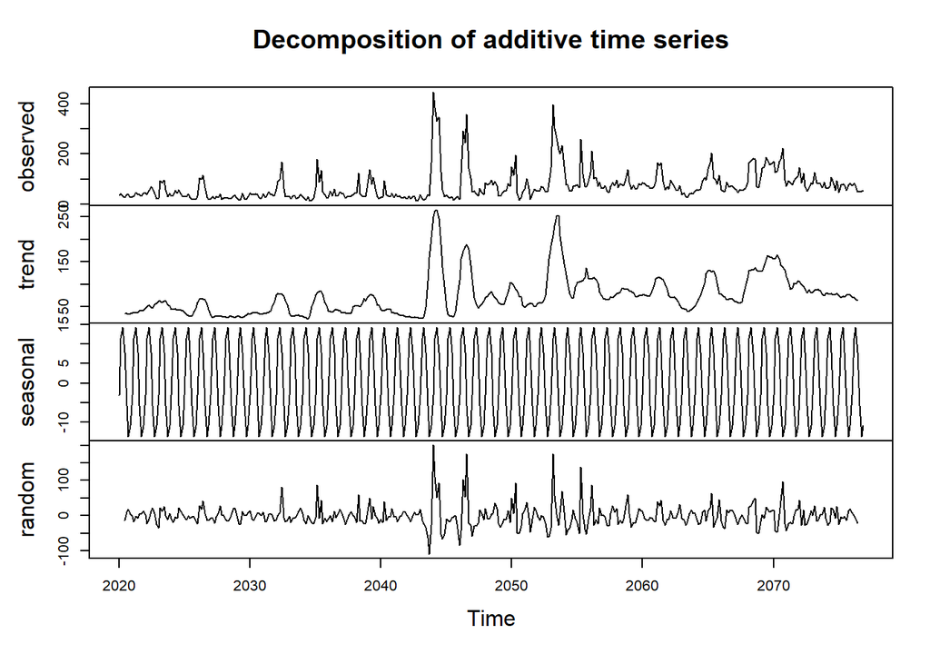

```
##
## #######################
## # KPSS Unit Root Test #
## #######################
##
## Test is of type: mu with 5 lags.
##
## Value of test-statistic is: 0.0061
##
## Critical value for a significance level of:
##                 10pct  5pct 2.5pct  1pct
## critical values 0.347 0.463  0.574 0.739
```

The results from unit root test belong to the random component of decomposition. Since its significance value is lower than the significance levels, the null hypothesis is failed to be rejected. The null hypothesis is that the data is stationary.

If the plot is analyzed, it can be seen that there is a slight upward trend, and there are some outliers, probably occurring in special days.

Weekly and monthly decomposition cannot be applied because the data do not include sales happened in 2 years. There are less than two periods. Therefore, this type of decomposition brings an error message.

Now, the autocorrelation and partial autocorrelation graphs will be analyzed.

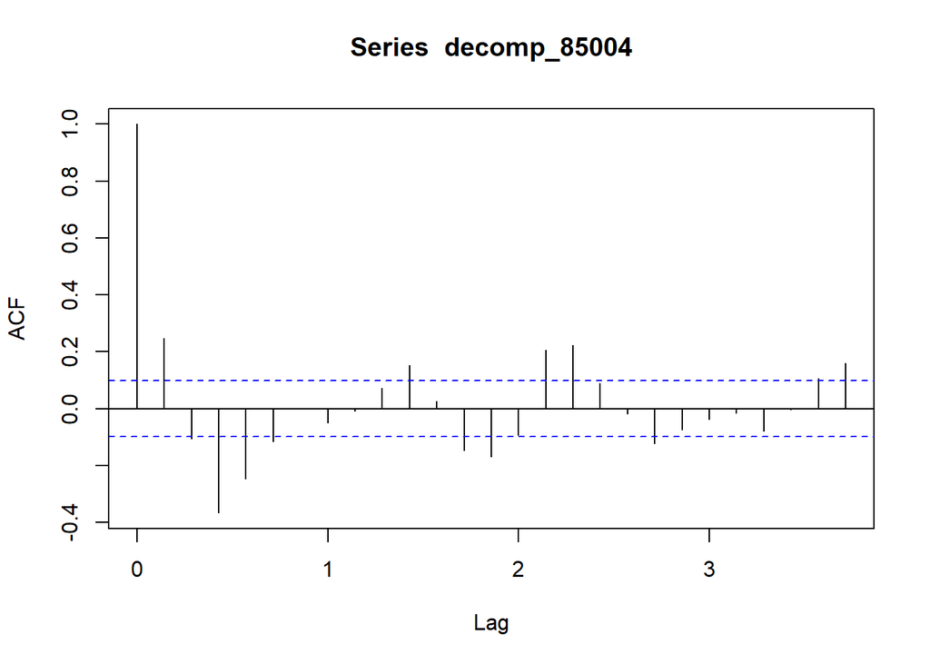

```r
acf(decomp_85004, na.action = na.pass)
```

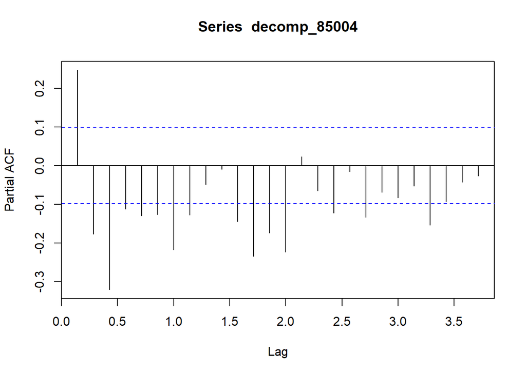

```r
pacf(decomp_85004, na.action = na.pass)
```

There is a significant autocorrelation in lag-1 and exponential decay can be seen in this graph. In partial autocorrelation graph, there is a sudden decrease after lag-1, and the other lags have negative autocorrelation. Seasonal autocorrelation is not observed in these graphs.

### Task 2

According to the plots above, ARIMA (1,0,0) can be applied as a baseline model.

```r
model1 <- arima(decomp_85004, order = c(1,0,0))
summary(model1)
```

```
##
## Call:
## arima(x = decomp_85004, order = c(1, 0, 0))
##
## Coefficients:
##          ar1  intercept
##       0.2466    -0.0300
## s.e.  0.0488     2.0809
##
## sigma^2 estimated as 967.6:  log likelihood = -1908.57,  aic = 3823.15
##
## Training set error measures:
##                       ME     RMSE      MAE      MPE     MAPE      MASE
## Training set 0.009354584 31.10615 19.89165 58.93116 148.3303 0.8090659
##                    ACF1
## Training set 0.04421066
```

Since lag-3 variable has a significant autocorrelation, ARIMA (3,0,0) can also be tried.

```r
model2 <- arima(decomp_85004, order = c(3,0,0))
summary(model2)
```

```
##
## Call:
## arima(x = decomp_85004, order = c(3, 0, 0))
##
## Coefficients:
##          ar1      ar2      ar3  intercept
##       0.2337  -0.0837  -0.3192    -0.0055
## s.e.  0.0477   0.0489   0.0476     1.2531
##
## sigma^2 estimated as 840.4:  log likelihood = -1881.08,  aic = 3772.16
##
## Training set error measures:
##                      ME     RMSE     MAE      MPE    MAPE      MASE        ACF1
## Training set 0.01427997 28.99012 18.2404 42.76788 188.251 0.7419034 -0.03548906
```

Lastly, lag-4 variable has also significant autocorrelation, and it is the last variable being significant. The model is below.

```r
model3 <- arima(decomp_85004, order = c(4,0,0))
summary(model3)
```

```
##
## Call:
## arima(x = decomp_85004, order = c(4, 0, 0))
##
## Coefficients:
##          ar1      ar2      ar3      ar4  intercept
##       0.1978  -0.0930  -0.2932  -0.1109    -0.0027
## s.e.  0.0501   0.0488   0.0488   0.0499     1.1213
##
## sigma^2 estimated as 829.9:  log likelihood = -1878.63,  aic = 3769.26
##
## Training set error measures:
##                     ME     RMSE      MAE      MPE     MAPE      MASE
## Training set 0.0149663 28.80806 18.12071 32.11328 201.7454 0.7370354
##                     ACF1
## Training set -0.01431356
```

The lowest AIC value belongs to ARIMA (4,0,0) model. It can be seen that AIC value of ARIMA (3,0,0) and AIC value of ARIMA(4,0,0) are very close to each other. Adding more variables would increase the complexity, which is not intended. Therefore, this model can be chosen as the last model.

It is interesting that the sales occurred three days ago has a significant negative effect on the current sales.

### Task 3

In the project, most variables (basket_count, favored_count, category_sold) are not independent. Therefore, using multiple regressors on the model is not appropriate. It will arise multicollinearity problem.

Now, the correlation matrix will be observed.

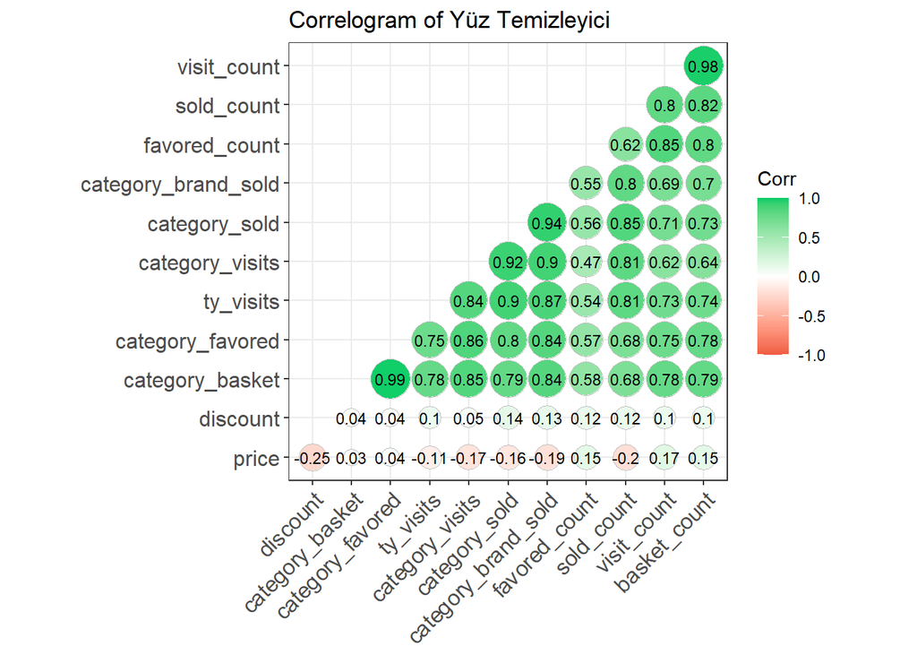

```r
cor_plot(data_85004, "Yüz Temizleyici")
```

The number of sales have high correlation with category_sold, basket_count, and category_visit. Since the features are scaled differently, they should be normalized.

### Task 4

```r
data_85004_norm <- data_manip("85004", normal = T)
model4 <- arima(decomp_85004, order = c(4,0,0), xreg = cbind(data_85004_norm$category_sold))
summary(model4)
```

```
##
## Call:
## arima(x = decomp_85004, order = c(4, 0, 0), xreg = cbind(data_85004_norm$category_sold))
##
## Coefficients:
##          ar1      ar2      ar3     ar4  intercept
##       0.4353  -0.0058  -0.1970  0.2206    -0.2107
## s.e.  0.0640   0.0546   0.0537  0.0524     2.1697
##       cbind(data_85004_norm$category_sold)
##                                    25.9015
## s.e.                                2.3926
##
## sigma^2 estimated as 556.9:  log likelihood = -1800.19,  aic = 3614.38
##
## Training set error measures:
##                        ME     RMSE      MAE       MPE     MAPE      MASE
## Training set 0.0001624377 23.59839 16.71755 -78.71831 320.5869 0.6799636
##                     ACF1
## Training set -0.02322312
```

It can be said that AIC value decreases, which is preferred.

Now, basket_count will be added, instead of category_sold.

```r
model5 <- arima(decomp_85004, order = c(4,0,0), xreg = cbind(data_85004_norm$basket_count))
summary(model5)
```

```
##
## Call:
## arima(x = decomp_85004, order = c(4, 0, 0), xreg = cbind(data_85004_norm$basket_count))
##
## Coefficients:
##         ar1     ar2      ar3     ar4  intercept
##       0.493  0.1612  -0.0578  0.2672     0.5393
## s.e.  0.049  0.0551   0.0551  0.0497     8.8115
##       cbind(data_85004_norm$basket_count)
##                                   40.5112
## s.e.                               2.3229
##
## sigma^2 estimated as 603.6:  log likelihood = -1816.42,  aic = 3646.84
##
## Training set error measures:
##                      ME     RMSE      MAE       MPE     MAPE      MASE
## Training set -0.1744417 24.56843 16.61896 -124.7445 326.3701 0.6759538
##                     ACF1
## Training set -0.05429853
```

It has higher AIC value, compared to the model with category_sold. Therefore, it will not be chosen as final model.

Now, lastly, category_visits will be used as a regressor.

```r
model6 <- arima(decomp_85004, order = c(4,0,0), xreg = cbind(data_85004_norm$category_visits))
summary(model6)
```

```
##
## Call:
## arima(x = decomp_85004, order = c(4, 0, 0), xreg = cbind(data_85004_norm$category_visits))
##
## Coefficients:
##          ar1      ar2      ar3     ar4  intercept
##       0.2503  -0.0838  -0.2720  0.0932    -0.1135
## s.e.  0.0848   0.0585   0.0566  0.0864     1.2069
##       cbind(data_85004_norm$category_visits)
##                                      18.2364
## s.e.                                  3.1085
##
## sigma^2 estimated as 585.5:  log likelihood = -1809.99,  aic = 3633.97
##
## Training set error measures:
##                      ME     RMSE      MAE       MPE     MAPE      MASE
## Training set 0.01356929 24.19623 16.78329 -137.1836 378.3565 0.6826374
##                      ACF1
## Training set -0.004464586
```

This model has a lower AIC value compared to the previous model, but the lowest AIC value belongs to the first model, with the number of sold products in the same category. Therefore, model with category_sold will be used as a final model.

Now, forecasts for the last week will be made.

```r
comparison_85004 <- forecast_func(data = data_85004$sold_count, ar_order = c(4,0,0), reg_matrix = cbind(data_85004_norm$category_sold))
```

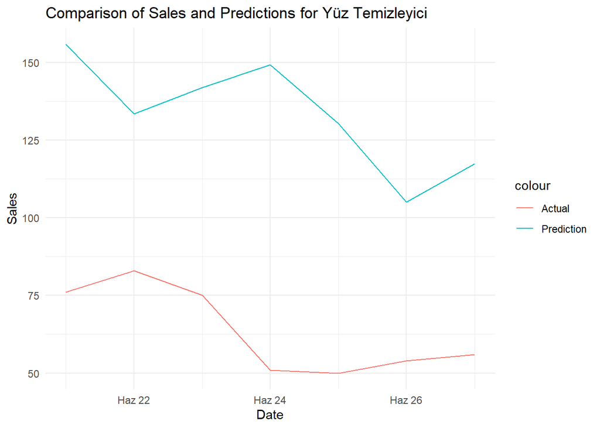

```r
comparison_85004 <- data.table(cbind(data_85004$event_date[(nrow(data_85004)-6):nrow(data_85004)], comparison_85004))
colnames(comparison_85004) <- c("event_date", "Actual", "Prediction")
plotting(comparison_85004,product_name = "Yüz Temizleyici", col = "",num =2)
```

It is obvious that the predictions are always larger than the actual sales. The reason may be the sales in January are very high and the number of sales decreases in the last month. If the seasonal term was added, the model would perform better, like in project.

The error rates are below.

```r
accu(comparison_85004$Actual, comparison_85004$Prediction)
```

```
##   n     mean       sd        CV     FBias     MAPE     RMSE      MAD     MADP
## 1 7 63.57143 13.86671 0.2181281 -1.097157 1.160731 71.59575 69.74785 1.097157
##      WMAPE
## 1 1.097157
```

As expected, its WMAPE is very high. Our model does not perform well. The reason behind is mentioned above. Unlike the project, there is no seasonal component.

## 2) Bluetooth Kulaklık

### Task 1

The data is imported.

```r
data_6676673 <- data_manip("6676673", normal = F)
head(data_6676673)
```

```
##    event_date    price sold_count visit_count basket_count favored_count
## 1: 2020-05-25 137.6873        539       21850         1783          1443
## 2: 2020-05-26 134.4552        724       25401         2106          1721
## 3: 2020-05-27 136.8115        763       27380         2286          1876
## 4: 2020-05-28 138.8387        597       22004         1797          1455
## 5: 2020-05-29 136.1015        695       22675         1858          1508
## 6: 2020-05-30 134.7339        587       21608         1761          1424
##    category_sold category_visits category_basket category_favored
## 1:           674           10271          319887            25365
## 2:           882            4546          223382            16909
## 3:           944            4346          198549            14733
## 4:           758            4371          207371            15506
## 5:           860            3833          180049            13112
## 6:           756            3456          176009            12758
##    category_brand_sold ty_visits  discount
## 1:               20525 109186825  0.000000
## 2:               22745 113831777  3.232121
## 3:               23407 115216330 -2.356326
## 4:               21422 111062671 -2.027127
## 5:               22510 113340484  2.737164
## 6:               21400 111018008  1.367595
```

The daily decomposition is made below.

```r
decomp_6676673 <- decomp(data_6676673, 7)
```

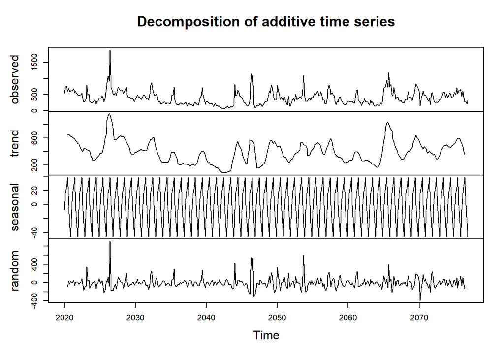

```
##
## #######################
## # KPSS Unit Root Test #
## #######################
##
## Test is of type: mu with 5 lags.
##
## Value of test-statistic is: 0.0081
##
## Critical value for a significance level of:
##                 10pct  5pct 2.5pct  1pct
## critical values 0.347 0.463  0.574 0.739
```

Since the significance value is lower than the significance levels, the null hypothesis is failed to be rejected. The null hypothesis is that the data is stationary.

When the plot is analyzed, it can be realized that there is a decreasing trend at the last days. However, in general, there is no obvious trend. The sales fluctuate a lot.

Weekly and monthly decomposition cannot be applied because the data do not include sales happened in 2 years. There are less than two periods. Therefore, this type of decomposition brings an error message.

Now, the autocorrelation and partial autocorrelation graphs will be interpretted.

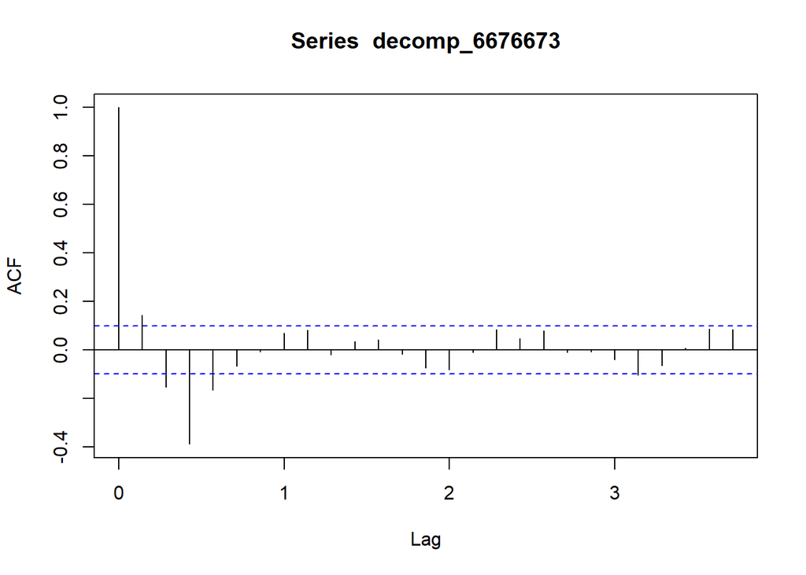

```r
acf(decomp_6676673, na.action = na.pass)
```

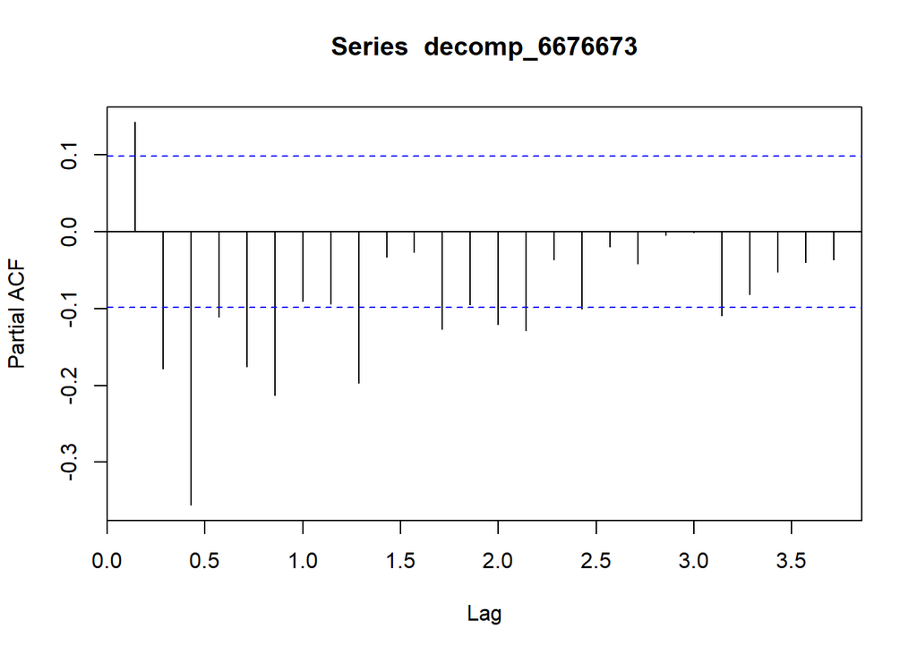

```r
pacf(decomp_6676673, na.action = na.pass)
```

There is a significant autocorrelation in lag-1 and exponential decay can be seen in this graph. In partial autocorrelation graph, there is a sudden decrease after lag-1, and the other lags have negative autocorrelation. Seasonal autocorrelation is not observed in these graphs.

### Task 2

According to the plots above, ARIMA (1,0,0) can be applied as a baseline model.

```r
model1 <- arima(decomp_6676673, order = c(1,0,0))
summary(model1)
```

```
##
## Call:
## arima(x = decomp_6676673, order = c(1, 0, 0))
##
## Coefficients:
##          ar1  intercept
##       0.1424    -0.0590
## s.e.  0.0500     6.9516
##
## sigma^2 estimated as 13978:  log likelihood = -2433.29,  aic = 4872.58
##
## Training set error measures:
##                       ME     RMSE      MAE      MPE     MAPE      MASE
## Training set -0.00365306 118.2273 74.59765 92.65507 127.3235 0.7856261
##                    ACF1
## Training set 0.02545937
```

Since lag-2 variable has a significant autocorrelation, ARIMA (2,0,0) can also be tried.

```r
model2 <- arima(decomp_6676673, order = c(2,0,0))
summary(model2)
```

```
##
## Call:
## arima(x = decomp_6676673, order = c(2, 0, 0))
##
## Coefficients:
##          ar1      ar2  intercept
##       0.1679  -0.1779    -0.0186
## s.e.  0.0497   0.0496     5.8128
##
## sigma^2 estimated as 13533:  log likelihood = -2426.97,  aic = 4861.93
##
## Training set error measures:
##                      ME     RMSE    MAE      MPE     MAPE      MASE        ACF1
## Training set 0.01287377 116.3307 72.519 94.92378 158.3284 0.7637348 -0.06321928
```

Lastly, lag-3 variable has also significant autocorrelation, and it is the last variable being significant. Its partial autocorrelation is very significant. The model is below.

```r
model3 <- arima(decomp_6676673, order = c(3,0,0))
summary(model3)
```

```
##
## Call:
## arima(x = decomp_6676673, order = c(3, 0, 0))
##
## Coefficients:
##          ar1      ar2      ar3  intercept
##       0.1048  -0.1178  -0.3554     0.0551
## s.e.  0.0471   0.0470   0.0471     4.0151
##
## sigma^2 estimated as 11809:  log likelihood = -2400.4,  aic = 4810.8
##
## Training set error measures:
##                       ME     RMSE      MAE     MPE     MAPE      MASE
## Training set -0.05308118 108.6706 69.25685 66.3144 218.8212 0.7293794
##                     ACF1
## Training set -0.03836247
```

The last model, ARIMA (3,0,0) has the lowest AIC value. Adding more variables would increase the complexity and the predictions cannot improve suddenly. Therefore, this model can be chosen as the last model.

### Task 3

In the project, most variables (basket_count, favored_count, category_sold) are not independent. Therefore, using multiple regressors on the model is not appropriate. It will arise multicollinearity problem.

Now, the correlation matrix will be observed.

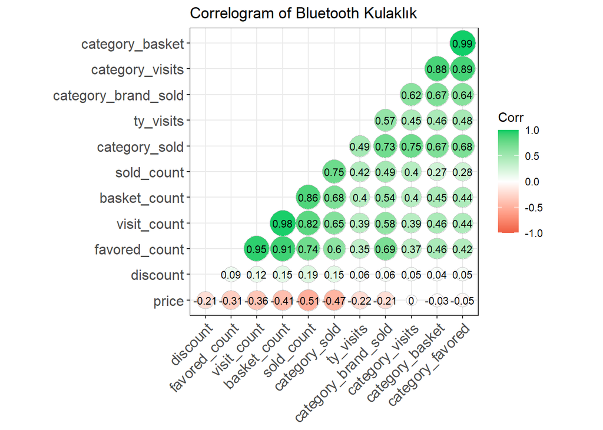

```r
cor_plot(data_6676673, "Bluetooth Kulaklık")
```

The number of sales have high correlation with visit_count, basket_count, and category_sold. Since the features are scaled differently, they should be normalized. In addition, price has a strong negative correlation with the number of sales. Therefore, it can be added into the model.

### Task 4

```r
data_6676673_norm <- data_manip("6676673", normal = T)
model4 <- arima(decomp_6676673, order = c(3,0,0), xreg = cbind(data_6676673_norm$category_sold, data_6676673_norm$price))
summary(model4)
```

```
##
## Call:
## arima(x = decomp_6676673, order = c(3, 0, 0), xreg = cbind(data_6676673_norm$category_sold,
##     data_6676673_norm$price))
##
## Coefficients:
##          ar1      ar2      ar3  intercept
##       0.1610  -0.0920  -0.2646   -90.8411
## s.e.  0.0623   0.0543   0.0628    48.8740
##       cbind(data_6676673_norm$category_sold, data_6676673_norm$price)1
##                                                                54.6718
## s.e.                                                            8.0607
##       cbind(data_6676673_norm$category_sold, data_6676673_norm$price)2
##                                                                 0.6679
## s.e.                                                            0.3591
##
## sigma^2 estimated as 9056:  log likelihood = -2348.13,  aic = 4710.26
##
## Training set error measures:
##                       ME     RMSE      MAE     MPE     MAPE      MASE
## Training set -0.01565502 95.16138 65.87713 113.274 346.2983 0.6937859
##                    ACF1
## Training set 0.01599591
```

AIC value of the last model is lower than the model without the regressor. It can be said that this model is superior.

Now, basket_count will be added, instead of category_sold.

```r
model5 <- arima(decomp_6676673, order = c(3,0,0), xreg = cbind(data_6676673_norm$basket_count, data_6676673_norm$price))
summary(model5)
```

```
##
## Call:
## arima(x = decomp_6676673, order = c(3, 0, 0), xreg = cbind(data_6676673_norm$basket_count,
##     data_6676673_norm$price))
##
## Coefficients:
##          ar1      ar2      ar3  intercept
##       0.1282  -0.1078  -0.2972   -42.0739
## s.e.  0.0546   0.0510   0.0557    42.8633
##       cbind(data_6676673_norm$basket_count, data_6676673_norm$price)1
##                                                               50.8962
## s.e.                                                           6.0049
##       cbind(data_6676673_norm$basket_count, data_6676673_norm$price)2
##                                                                0.3107
## s.e.                                                           0.3150
##
## sigma^2 estimated as 8829:  log likelihood = -2343.19,  aic = 4700.38
##
## Training set error measures:
##                       ME     RMSE      MAE      MPE     MAPE      MASE
## Training set -0.07665345 93.96506 64.40542 77.25282 323.9058 0.6782865
##                     ACF1
## Training set 0.006499918
```

It has lower AIC value, compared to the model with category_sold. This model is better.

Now, lastly, visit_count will be used as a regressor.

```r
model6 <- arima(decomp_6676673, order = c(3,0,0), xreg = cbind(data_6676673_norm$visit_count, data_6676673_norm$price))
summary(model6)
```

```
##
## Call:
## arima(x = decomp_6676673, order = c(3, 0, 0), xreg = cbind(data_6676673_norm$visit_count,
##     data_6676673_norm$price))
##
## Coefficients:
##          ar1      ar2      ar3  intercept
##       0.1323  -0.1108  -0.3036    -6.6193
## s.e.  0.0532   0.0502   0.0539    42.5681
##       cbind(data_6676673_norm$visit_count, data_6676673_norm$price)1
##                                                              46.7090
## s.e.                                                          5.6364
##       cbind(data_6676673_norm$visit_count, data_6676673_norm$price)2
##                                                               0.0491
## s.e.                                                          0.3128
##
## sigma^2 estimated as 9127:  log likelihood = -2349.7,  aic = 4713.41
##
## Training set error measures:
##                       ME     RMSE      MAE      MPE     MAPE      MASE
## Training set -0.07348484 95.53383 65.73031 76.93394 313.1336 0.6922396
##                     ACF1
## Training set 0.002902161
```

This model has a higher AIC value compared to the previous model. According to the results the model with basket_count will be used as a final model.

Now, forecasts for the last week will be made.

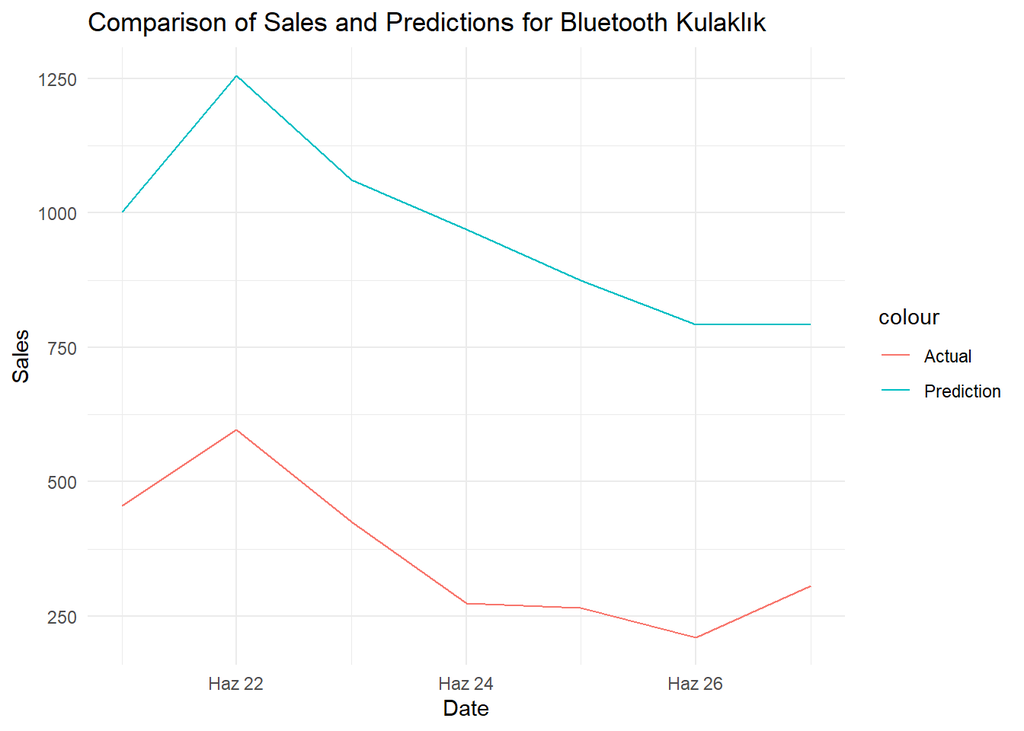

```r
comparison_6676673 <- forecast_func(data = data_6676673$sold_count, ar_order = c(3,0,0), reg_matrix = cbind(data_6676673_norm$basket_count, data_6676673_norm$price))
comparison_6676673 <- data.table(cbind(data_6676673$event_date[(nrow(data_6676673)-6):nrow(data_6676673)], comparison_6676673))
colnames(comparison_6676673) <- c("event_date", "Actual", "Prediction")
plotting(comparison_6676673,product_name = "Bluetooth Kulaklık", col = "",num =2)
```

It is obvious that the predictions are always larger than the actual sales, like the other products. If the seasonal term was added, the model would perform better, like in project. In addition, the model is successful for the catching changes. When the actual sale decreases, the prediction also decreases, and vice versa.

The error rates are below.

```r
accu(comparison_6676673$Actual, comparison_6676673$Prediction)
```

```
##   n mean       sd        CV     FBias    MAPE     RMSE      MAD     MADP
## 1 7  362 135.8553 0.3752909 -1.663524 1.85408 605.6803 602.1955 1.663524
##      WMAPE
## 1 1.663524
```

As expected, its WMAPE is very high. Our model does not perform well. The reason behind is mentioned above.

## 3) Bikini Üstü (2)

### Task 1

The data is imported.

```r
data_32737302 <- data_manip("32737302", normal = F)
head(data_32737302)
```

```
##    event_date price sold_count visit_count basket_count favored_count
## 1: 2020-05-25 59.99         40        3191          211           385
## 2: 2020-05-26 59.99         44        3191          211           385
## 3: 2020-05-27 59.99         33        2183          141           241
## 4: 2020-05-28 59.99         33        2313          150           259
## 5: 2020-05-29 59.99         33        2471          161           282
## 6: 2020-05-30 59.99         39        2586          169           298
##    category_sold category_visits category_basket category_favored
## 1:          1365            1806          274764             9738
## 2:          1223            1700          246892             8778
## 3:           848            1164          150675             5464
## 4:           722            1052          153636             5566
## 5:           968            1374          207058             7406
## 6:          1279            1758          255544             9076
##    category_brand_sold ty_visits discount
## 1:               38084 112754071        0
## 2:               35220 111701576        0
## 3:               27656 108922100        0
## 4:               25115 107988196        0
## 5:               30077 109811532        0
## 6:               36349 112116645        0
```

The daily decomposition is made below.

```r
decomp_32737302 <- decomp(data_32737302, 7)
```

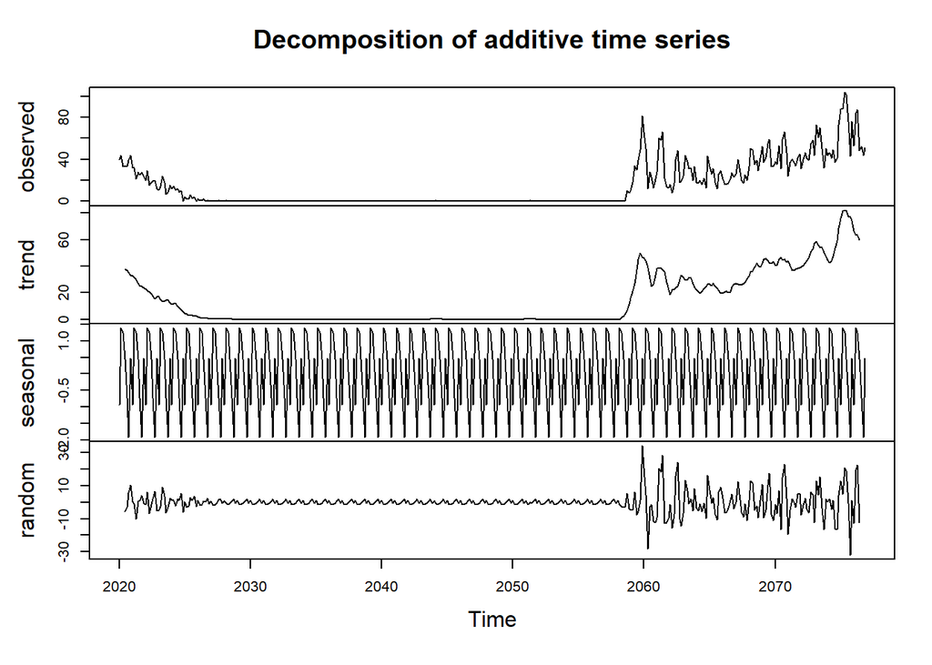

```
##
## #######################
## # KPSS Unit Root Test #
## #######################
##
## Test is of type: mu with 5 lags.
##
## Value of test-statistic is: 0.0156
##
## Critical value for a significance level of:
##                 10pct  5pct 2.5pct  1pct
## critical values 0.347 0.463  0.574 0.739
```

Since people tend to buy bikini during the Spring and Summer, the number of sales in Winter and Fall is almost zero. There is an upward trend after March 2021.

Now, their autocorrelation and partial autocorrelation plots will be observed.

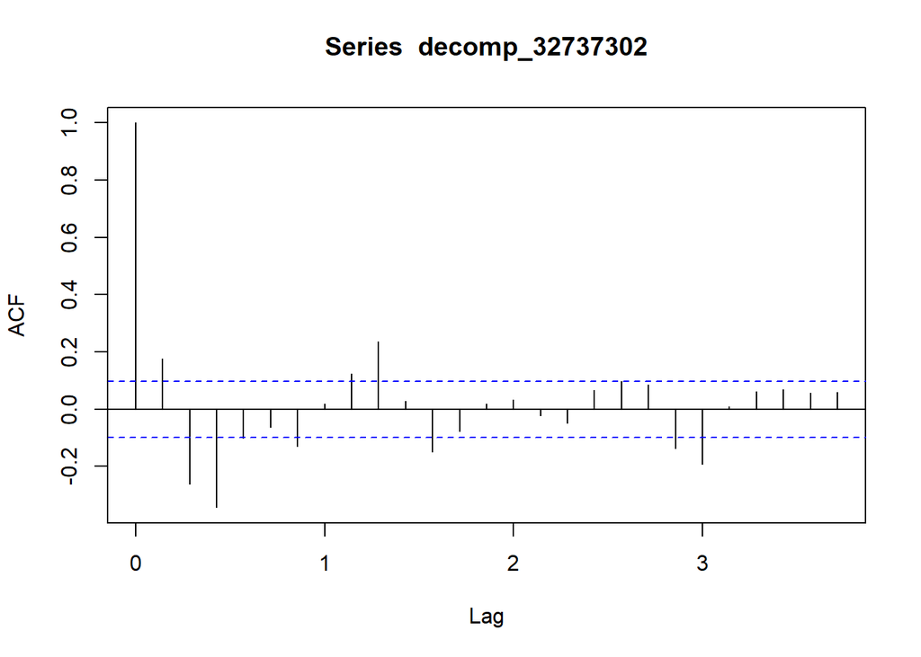

```r
acf(decomp_32737302, na.action = na.pass)
```

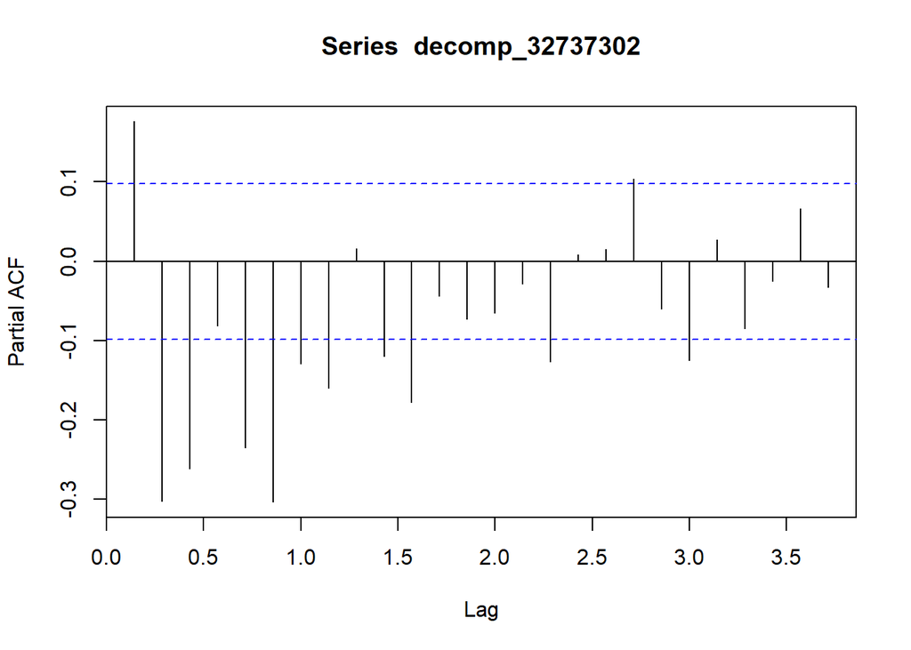

```r
pacf(decomp_32737302, na.action = na.pass)
```

There is a significant autocorrelation in lag-1. In partial autocorrelation graph, there is a sudden decrease after lag-1, and the other lags have negative autocorrelation. Seasonal autocorrelation is not observed in these graphs. These graphs are very similar to the other products’ autocorrelation and partial autocorrelation graphs.

### Task 2

According to the plots above, ARIMA (1,0,0) can be applied as a baseline model.

```r
model1 <- arima(decomp_32737302, order = c(1,0,0))
summary(model1)
```

```
##
## Call:
## arima(x = decomp_32737302, order = c(1, 0, 0))
##
## Coefficients:
##          ar1  intercept
##       0.1774     0.0196
## s.e.  0.0498     0.3934
##
## sigma^2 estimated as 41.2:  log likelihood = -1288.31,  aic = 2582.62
##
## Training set error measures:
##                       ME     RMSE      MAE      MPE     MAPE      MASE
## Training set 0.002697806 6.418337 3.680862 99.52789 113.1288 0.7701051
##                    ACF1
## Training set 0.05434223
```

Since lag-2 variable has a significant autocorrelation, ARIMA (2,0,0) can also be tried.

```r
model2 <- arima(decomp_32737302, order = c(2,0,0))
summary(model2)
```

```
##
## Call:
## arima(x = decomp_32737302, order = c(2, 0, 0))
##
## Coefficients:
##          ar1      ar2  intercept
##       0.2393  -0.3194     0.0183
## s.e.  0.0483   0.0490     0.2849
##
## sigma^2 estimated as 37.15:  log likelihood = -1268.12,  aic = 2544.24
##
## Training set error measures:
##                        ME     RMSE     MAE      MPE     MAPE    MASE
## Training set -0.003258286 6.095244 3.51417 80.20563 140.2229 0.73523
##                     ACF1
## Training set -0.08382818
```

Lastly, lag-3 variable has also significant autocorrelation, and it is the last variable being significant. Its partial autocorrelation is very significant. The model is below.

```r
model3 <- arima(decomp_32737302, order = c(3,0,0))
summary(model3)
```

```
##
## Call:
## arima(x = decomp_32737302, order = c(3, 0, 0))
##
## Coefficients:
##          ar1      ar2      ar3  intercept
##       0.1573  -0.2547  -0.2776     0.0100
## s.e.  0.0487   0.0485   0.0498     0.2157
##
## sigma^2 estimated as 34.41:  log likelihood = -1253.16,  aic = 2516.32
##
## Training set error measures:
##                        ME     RMSE      MAE      MPE     MAPE      MASE
## Training set -0.003733522 5.865789 3.336035 65.12503 138.9254 0.6979609
##                     ACF1
## Training set -0.01845377
```

The last model, ARIMA (3,0,0) has the lowest AIC value. Adding more variables would increase the complexity and the predictions cannot improve suddenly. Therefore, this model can be chosen as the last model.

The effects of the sales occurred in 2 days ago and 3 days ago are almost same.

### Task 3

Now, the correlation matrix will be observed.

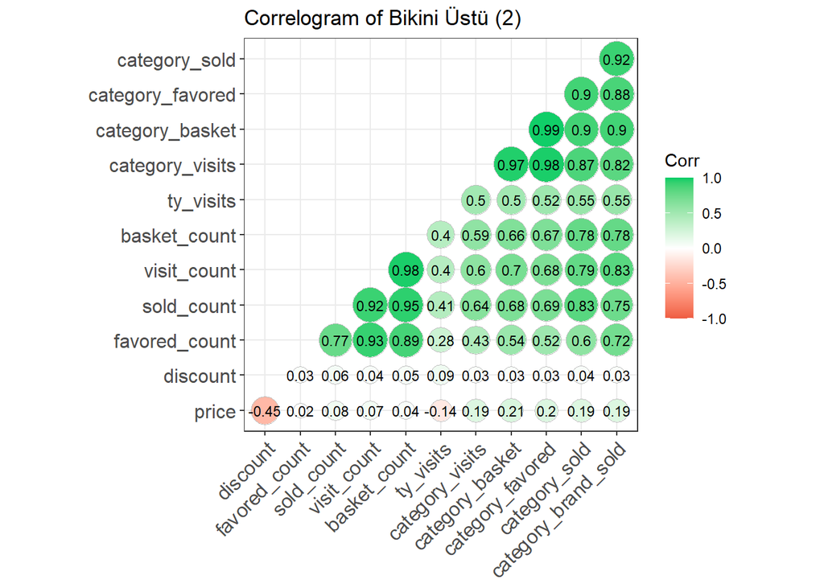

```r
cor_plot(data_32737302, "Bikini Üstü (2)")
```

The number of sales have high correlation with visit_count, basket_count, and favored_count. Since the features are scaled differently, they should be normalized.

Now, the models will be constructed by using these features one by one.

### Task 4

```r
data_32737302_norm <- data_manip("32737302", normal = T)
model4 <- arima(decomp_32737302, order = c(3,0,0), xreg = cbind(data_32737302_norm$visit_count))
summary(model4)
```

```
##
## Call:
## arima(x = decomp_32737302, order = c(3, 0, 0), xreg = cbind(data_32737302_norm$visit_count))
##
## Coefficients:
##          ar1      ar2      ar3  intercept
##       0.1508  -0.2587  -0.2743     0.0348
## s.e.  0.0491   0.0485   0.0504     0.2109
##       cbind(data_32737302_norm$visit_count)
##                                      0.8363
## s.e.                                 0.2264
##
## sigma^2 estimated as 33.22:  log likelihood = -1246.23,  aic = 2504.46
##
## Training set error measures:
##                        ME     RMSE      MAE      MPE     MAPE      MASE
## Training set -0.005202095 5.763299 3.300996 64.64493 120.6665 0.6906299
##                    ACF1
## Training set -0.0132655
```

AIC value of the last model is slightly lower than the model without the regressor. It can be said that this model is superior.

Now, basket_count will be added, instead of visit count.

```r
model5 <- arima(decomp_32737302, order = c(3,0,0), xreg = cbind(data_32737302_norm$basket_count))
summary(model5)
```

```
##
## Call:
## arima(x = decomp_32737302, order = c(3, 0, 0), xreg = cbind(data_32737302_norm$basket_count))
##
## Coefficients:
##          ar1      ar2      ar3  intercept
##       0.1565  -0.2513  -0.2700     0.0339
## s.e.  0.0495   0.0489   0.0507     0.2126
##       cbind(data_32737302_norm$basket_count)
##                                       0.9305
## s.e.                                  0.2299
##
## sigma^2 estimated as 32.93:  log likelihood = -1244.55,  aic = 2501.11
##
## Training set error measures:
##                        ME     RMSE      MAE      MPE     MAPE     MASE
## Training set -0.005218935 5.738889 3.300982 65.25441 121.8915 0.690627
##                     ACF1
## Training set -0.01016151
```

Now, lastly, favored_count will be used as a regressor.

```r
model6 <- arima(decomp_32737302, order = c(3,0,0), xreg = cbind(data_32737302_norm$favored_count))
summary(model6)
```

```
##
## Call:
## arima(x = decomp_32737302, order = c(3, 0, 0), xreg = cbind(data_32737302_norm$favored_count))
##
## Coefficients:
##          ar1      ar2      ar3  intercept
##       0.1411  -0.2592  -0.2847     0.0272
## s.e.  0.0487   0.0483   0.0499     0.2074
##       cbind(data_32737302_norm$favored_count)
##                                        0.8924
## s.e.                                   0.2261
##
## sigma^2 estimated as 33.09:  log likelihood = -1245.48,  aic = 2502.97
##
## Training set error measures:
##                        ME     RMSE      MAE      MPE     MAPE     MASE
## Training set -0.005183828 5.752192 3.301584 64.59097 120.3607 0.690753
##                     ACF1
## Training set -0.01665027
```

This model has a marginally higher AIC value compared to the previous model. According to the results the model with basket_count will be used as a final model.

Now, forecasts for the last week will be made.

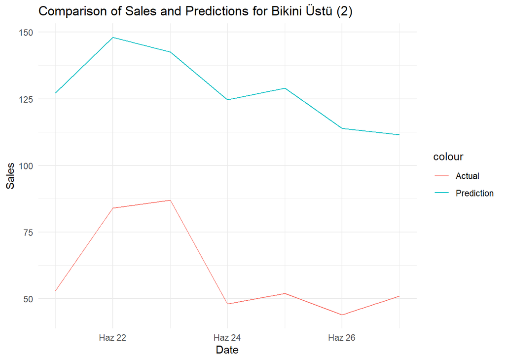

```r
comparison_32737302 <- forecast_func(data = data_32737302$sold_count, ar_order = c(3,0,0), reg_matrix = cbind(data_32737302_norm$basket_count))
comparison_32737302 <- data.table(cbind(data_32737302$event_date[(nrow(data_32737302)-6):nrow(data_32737302)], comparison_32737302))
colnames(comparison_32737302) <- c("event_date", "Actual", "Prediction")
plotting(comparison_32737302,product_name = "Bikini Üstü (2)", col = "",num =2)
```

The error rates are below.

```r
accu(comparison_32737302$Actual, comparison_32737302$Prediction)
```

```
##   n     mean       sd        CV     FBias     MAPE     RMSE      MAD     MADP
## 1 7 59.85714 17.78978 0.2972039 -1.141202 1.236991 68.74815 68.30909 1.141202
##      WMAPE
## 1 1.141202
```

As expected, its WMAPE is very high. Our model does not perform well. The reason behind is although the random component passes the unit root test, not having sales for months affects the model notoriously.

## 4) Dik Süpürge

### Task 1

Let’s examine the data of the “Dik Süpürge”.

```r
data_7061886 <- data_manip("7061886", normal = F)
head(data_7061886)
```

```
##    event_date    price sold_count visit_count basket_count favored_count
## 1: 2020-05-25 238.8718         39        2471          136           236
## 2: 2020-05-26 237.8758         33        2139          117           205
## 3: 2020-05-27 240.6333         36        2541          140           243
## 4: 2020-05-28 236.8132         38        2751          152           262
## 5: 2020-05-29 232.9308         39        2227          122           213
## 6: 2020-05-30 229.2183         71        3993          223           379
##    category_sold category_visits category_basket category_favored
## 1:           102             520           56048             2171
## 2:           110             508           55097             2118
## 3:           129             510           51490             1917
## 4:           140             529           54756             2099
## 5:           118             489           52369             1966
## 6:           162             608           57322             2242
##    category_brand_sold ty_visits   discount
## 1:                6727 105692032  0.0000000
## 2:                6956 107205276  0.9960373
## 3:                7498 110799229 -2.7575757
## 4:                7813 112879939  3.8201754
## 5:                7184 108718519  3.8823887
## 6:                8441 117041358  3.7124593
```

As we can see below, data set has no significant level of increasing variance over time, thus decomposition should be done in an “additive” way.

After the decomposition, let’s check the KPSS test results for stationary. The test shows that the value is way less than the significance threshold, thus we fail to reject the null hypothesis, which is the stationary of the data.

Also, if we try to decompose the data with a weekly and monthly perspective, we get an error since the dataset has no data that can support at least two periods. Therefore, we can only continue with the daily decomposition.

Furthermore, let’s analyze the ACF and PCF plots.

```r
decomp_7061886 <- decomp(data_7061886, 7)
```

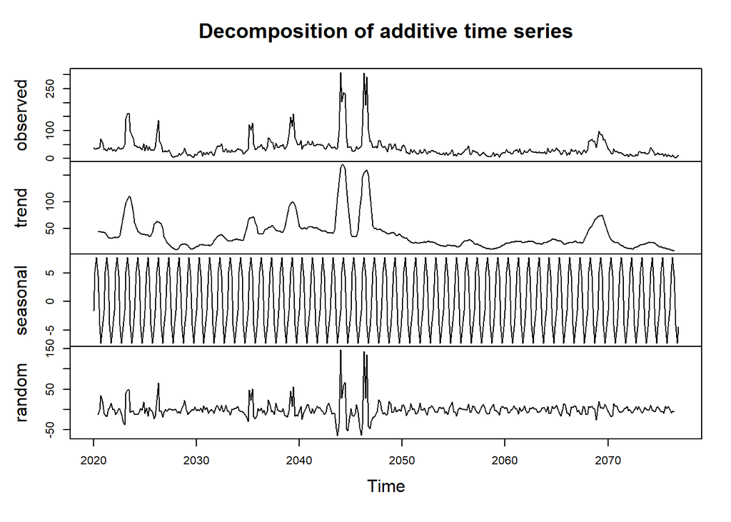

```
##
## #######################
## # KPSS Unit Root Test #
## #######################
##
## Test is of type: mu with 5 lags.
##
## Value of test-statistic is: 0.0068
##
## Critical value for a significance level of:
##                 10pct  5pct 2.5pct  1pct
## critical values 0.347 0.463  0.574 0.739
```

As we can see, the ACF plot shows that there’s an exponential decay. Also, PCF graph shows that lag-1 is significant and starting from lag-2, almost every lag is negative, and lag-3 has the highest significance in the negative domain. There’s no seasonal features observed in these plots.

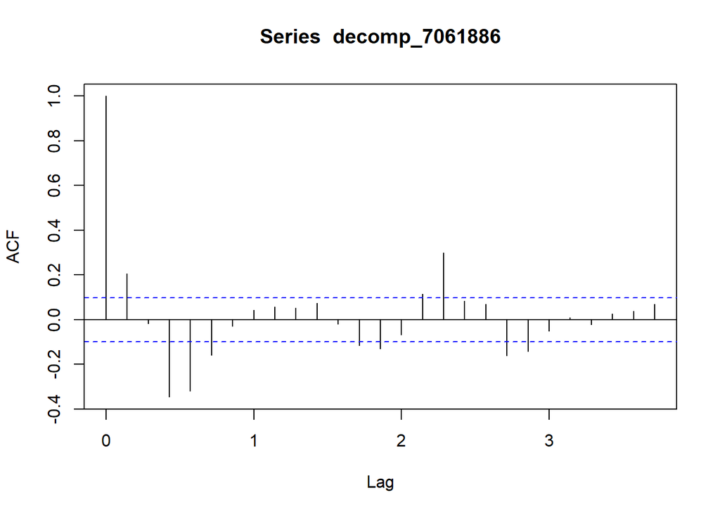

```r
acf(decomp_7061886, na.action = na.pass)
```

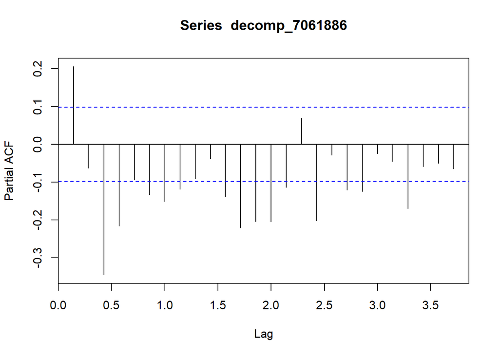

```r
pacf(decomp_7061886, na.action = na.pass)
```

### Task 2

According the plots above, we should use an ARIMA model with c(1, 0, 0) to observe the outputs. After that, I’ve tried (2, 0, 0), (3, 0, 0), (4, 0, 0), and (5, 0, 0) to see the difference between the models. And after the 6th order, the model has no significant change thus I’ve selected my model as (6, 0, 0).

```r
model1 <- arima(decomp_7061886, order = c(1,0,0))
summary(model1)
```

```
##
## Call:
## arima(x = decomp_7061886, order = c(1, 0, 0))
##
## Coefficients:
##          ar1  intercept
##       0.2049     0.0079
## s.e.  0.0493     1.2069
##
## sigma^2 estimated as 362.4:  log likelihood = -1715.6,  aic = 3437.2
##
## Training set error measures:
##                      ME     RMSE      MAE      MPE     MAPE      MASE
## Training set 0.00173562 19.03733 10.30929 451.9355 482.7022 0.8279748
##                    ACF1
## Training set 0.01321938
```

```r
model2 <- arima(decomp_7061886, order = c(2,0,0))
summary(model2)
```

```
##
## Call:
## arima(x = decomp_7061886, order = c(2, 0, 0))
##
## Coefficients:
##          ar1      ar2  intercept
##       0.2177  -0.0630     0.0092
## s.e.  0.0503   0.0502     1.1335
##
## sigma^2 estimated as 361:  log likelihood = -1714.82,  aic = 3437.63
##
## Training set error measures:
##                       ME     RMSE      MAE      MPE     MAPE      MASE
## Training set 0.001884731 18.99917 10.20014 478.1335 506.0391 0.8192085
##                     ACF1
## Training set -0.02144627
```

```r
model3 <- arima(decomp_7061886, order = c(3,0,0))
summary(model3)
```

```
##
## Call:
## arima(x = decomp_7061886, order = c(3, 0, 0))
##
## Coefficients:
##          ar1     ar2      ar3  intercept
##       0.1966  0.0125  -0.3464     0.0014
## s.e.  0.0472  0.0482   0.0473     0.7916
##
## sigma^2 estimated as 317.4:  log likelihood = -1689.74,  aic = 3389.47
##
## Training set error measures:
##                      ME     RMSE      MAE      MPE    MAPE      MASE
## Training set 0.02023501 17.81587 9.553373 822.4767 882.444 0.7672645
##                     ACF1
## Training set -0.07570482
```

```r
model4 <- arima(decomp_7061886, order = c(4,0,0))
summary(model4)
```

```
##
## Call:
## arima(x = decomp_7061886, order = c(4, 0, 0))
##
## Coefficients:
##          ar1     ar2      ar3      ar4  intercept
##       0.1209  0.0158  -0.3042  -0.2178    -0.0051
## s.e.  0.0491  0.0471   0.0471   0.0492     0.6349
##
## sigma^2 estimated as 302.2:  log likelihood = -1680.19,  aic = 3372.38
##
## Training set error measures:
##                      ME   RMSE      MAE      MPE     MAPE      MASE        ACF1
## Training set 0.03250532 17.384 9.368597 909.3851 976.1841 0.7524245 -0.02059675
```

```r
model5 <- arima(decomp_7061886, order = c(5,0,0))
summary(model5)
```

```
##
## Call:
## arima(x = decomp_7061886, order = c(5, 0, 0))
##
## Coefficients:
##          ar1      ar2      ar3      ar4      ar5  intercept
##       0.1006  -0.0122  -0.3022  -0.2069  -0.0918    -0.0054
## s.e.  0.0502   0.0493   0.0469   0.0494   0.0502     0.5794
##
## sigma^2 estimated as 299.6:  log likelihood = -1678.53,  aic = 3371.05
##
## Training set error measures:
##                      ME     RMSE      MAE      MPE    MAPE      MASE
## Training set 0.03316681 17.30968 9.374549 823.7522 910.548 0.7529025
##                     ACF1
## Training set -0.01268297
```

```r
model6 <- arima(decomp_7061886, order = c(6,0,0))
summary(model6)
```

```
##
## Call:
## arima(x = decomp_7061886, order = c(6, 0, 0))
##
## Coefficients:
##          ar1      ar2      ar3      ar4      ar5      ar6  intercept
##       0.0883  -0.0397  -0.3421  -0.2077  -0.0789  -0.1317    -0.0047
## s.e.  0.0499   0.0500   0.0490   0.0489   0.0500   0.0499     0.5079
##
## sigma^2 estimated as 294.3:  log likelihood = -1675.08,  aic = 3366.16
##
## Training set error measures:
##                      ME     RMSE      MAE      MPE     MAPE      MASE
## Training set 0.03286147 17.15631 9.381341 839.3245 956.9745 0.7534479
##                     ACF1
## Training set -0.02036132
```

By incrementing the order of the ARIMA model 1 at each time, we can see the change in the AIC value and after the (6, 0, 0) model, it was not efficient to increase the model complexity. Therefore, I’d like to use (6, 0, 0) in the future tasks.

### Task 3

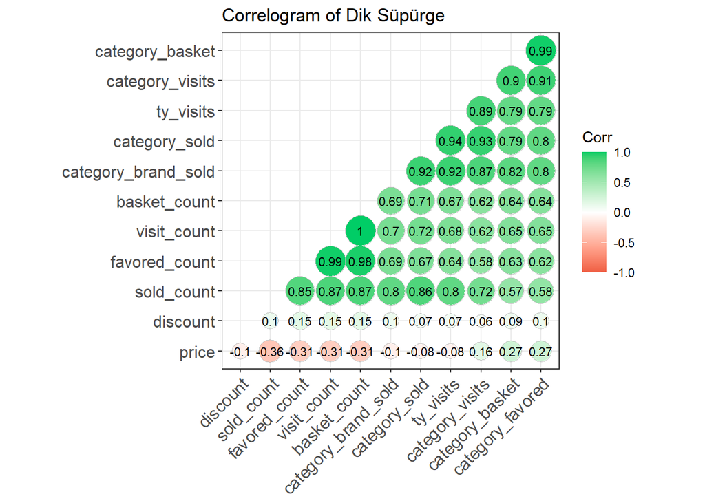

```r
cor_plot(data_7061886, "Dik Süpürge")
```

In the project, most of the variables (basket_count, favored_count, category_sold) are not independent. Therefore, using multiple regressors on a model for this data set is not a suitable approach. It will arise multicollinearity problem.

### Task 4

By looking the correlation plot, I’ve selected 3 distinct features to feed my ARIMA models and category_sold was the one that has given the smallest AIC value. Thus, I’ve selected my regressor as category_sold.

The block below tries visit_count as the regressor for the selected model in the previous task.

```r
data_7061886_norm <- data_manip("7061886", normal = T)
model7 <- arima(decomp_7061886, order = c(6,0,0), xreg = cbind(data_7061886_norm$visit_count))
summary(model7)
```

```
##
## Call:
## arima(x = decomp_7061886, order = c(6, 0, 0), xreg = cbind(data_7061886_norm$visit_count))
##
## Coefficients:
##          ar1      ar2      ar3      ar4      ar5      ar6  intercept
##       0.0479  -0.0406  -0.3322  -0.2234  -0.0725  -0.0899    -0.0471
## s.e.  0.0510   0.0518   0.0505   0.0495   0.0522   0.0548     0.4815
##       cbind(data_7061886_norm$visit_count)
##                                     3.9560
## s.e.                                0.6733
##
## sigma^2 estimated as 264.3:  log likelihood = -1653.87,  aic = 3325.73
##
## Training set error measures:
##                      ME     RMSE      MAE      MPE     MAPE      MASE
## Training set 0.03044494 16.25653 9.283638 461.0325 589.5924 0.7456011
##                     ACF1
## Training set -0.00817959
```

The block below tries basket_count as the regressor for the selected model in the previous task.

```r
model8 <- arima(decomp_7061886, order = c(6,0,0), xreg = cbind(data_7061886_norm$basket_count))
summary(model8)
```

```
##
## Call:
## arima(x = decomp_7061886, order = c(6, 0, 0), xreg = cbind(data_7061886_norm$basket_count))
##
## Coefficients:
##          ar1      ar2      ar3      ar4      ar5      ar6  intercept
##       0.0483  -0.0399  -0.3325  -0.2236  -0.0706  -0.0883    -0.0487
## s.e.  0.0511   0.0520   0.0505   0.0496   0.0524   0.0551     0.4819
##       cbind(data_7061886_norm$basket_count)
##                                      4.0196
## s.e.                                 0.6798
##
## sigma^2 estimated as 263.6:  log likelihood = -1653.33,  aic = 3324.65
##
## Training set error measures:
##                      ME     RMSE      MAE      MPE     MAPE      MASE
## Training set 0.03044897 16.23425 9.244897 459.4313 581.9289 0.7424897
##                      ACF1
## Training set -0.007852957
```

The block below tries category_sold as the regressor for the selected model in the previous task.

```r
model9 <- arima(decomp_7061886, order = c(6,0,0), xreg = cbind(data_7061886_norm$category_sold))
summary(model9)
```

```
##
## Call:
## arima(x = decomp_7061886, order = c(6, 0, 0), xreg = cbind(data_7061886_norm$category_sold))
##
## Coefficients:
##          ar1     ar2      ar3     ar4     ar5      ar6  intercept
##       0.7002  0.2054  -0.2605  0.1736  0.0407  -0.0634    -0.1221
## s.e.  0.0675  0.0622   0.0627  0.0620  0.0645   0.0505     3.1123
##       cbind(data_7061886_norm$category_sold)
##                                      26.0951
## s.e.                                  1.4255
##
## sigma^2 estimated as 161.7:  log likelihood = -1557.57,  aic = 3133.15
##
## Training set error measures:
##                      ME     RMSE      MAE      MPE     MAPE      MASE
## Training set 0.01630843 12.71697 8.860264 1493.742 1766.186 0.7115985
##                       ACF1
## Training set -0.0004039257
```

As we can see, category_sold has given the smallest AIC, thus my predictive model is utilizing category_sold as its external regressor. And the block below creates a model with the given specifications, constructs the predictions and plot them to compare the results.

The plot shows that predictions are way more than the actual values for quite a time, buy they get closer at the end of the predictions. This may occur due to the lack of seasonality in our data, since the data set has seasonal features, but we did not create a model with a seasonality option. Let’s check the WMAPE value for gaining more insight.

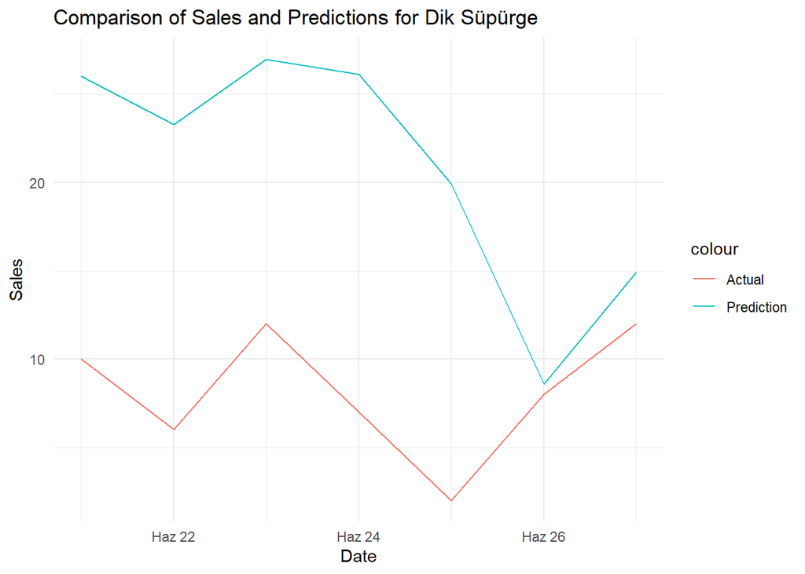

```r
comparison_7061886 <- forecast_func(data = data_7061886$sold_count, ar_order = c(6,0,0), reg_matrix = cbind(data_7061886_norm$category_sold))
comparison_7061886 <- data.table(cbind(data_7061886$event_date[(nrow(data_7061886)-6):nrow(data_7061886)], comparison_7061886))
colnames(comparison_7061886) <- c("event_date", "Actual", "Prediction")
plotting(comparison_7061886,product_name = "Dik Süpürge", col = "",num =2)
```

It is not a surprise for us to see that much WMAPE score, since our predictions are way off than the actual data. This also indicates that our model has functioned insufficiently and there’s much work to be done in future to improve this model.

```r
accu(comparison_7061886$Actual, comparison_7061886$Prediction)
```

```
##   n     mean      sd        CV     FBias     MAPE     RMSE      MAD     MADP
## 1 7 8.142857 3.57904 0.4395312 -1.559327 2.536658 14.52767 12.69738 1.559327
##      WMAPE
## 1 1.559327
```

## 5) Bebek Islak Mendil

### Task 1

Let’s examine the data of the “Bebek Islak Mendil”.

```r
data_4066298 <- data_manip("4066298", normal = F)
head(data_4066298)
```

```
##    event_date    price sold_count visit_count basket_count favored_count
## 1: 2020-05-25 76.05423        142        2070          307            92
## 2: 2020-05-26 75.78349        169        2154          330            99
## 3: 2020-05-27 76.92846        201        2406          399           121
## 4: 2020-05-28 77.21761        176        2191          340           103
## 5: 2020-05-29 76.98344        154        2030          296            89
## 6: 2020-05-30 77.15858        162        2016          292            88
##    category_sold category_visits category_basket category_favored
## 1:           413            1149           17326             2640
## 2:           486            1369           18807             3036
## 3:           562            1562           20289             3432
## 4:           550            1482           19597             3247
## 5:           473            1273           18126             2854
## 6:           494            1220           16783             2495
##    category_brand_sold ty_visits   discount
## 1:                2461 105438700  0.0000000
## 2:                2594 105956413  0.2707342
## 3:                2731 106495403 -1.1449666
## 4:                2710 106410299 -0.2891559
## 5:                2570 105864218  0.2341721
## 6:                2608 106013149 -0.1751387
```

As we can see below, data set has no significant level of increasing variance over time except for several outlying exceptions, thus decomposition should be done in an “additive” way.

After the decomposition, let’s check the KPSS test results for stationary. The test shows that the value is way less than the significance threshold, thus we fail to reject the null hypothesis, which is the stationary of the data.

Also, if we try to decompose the data with a weekly and monthly perspective, we get an error since the dataset has no data that can support at least two periods. Therefore, we can only continue with the daily decomposition.

Furthermore, let’s analyze the ACF and PCF plots.

```r
decomp_4066298 <- decomp(data_4066298, 7)
```

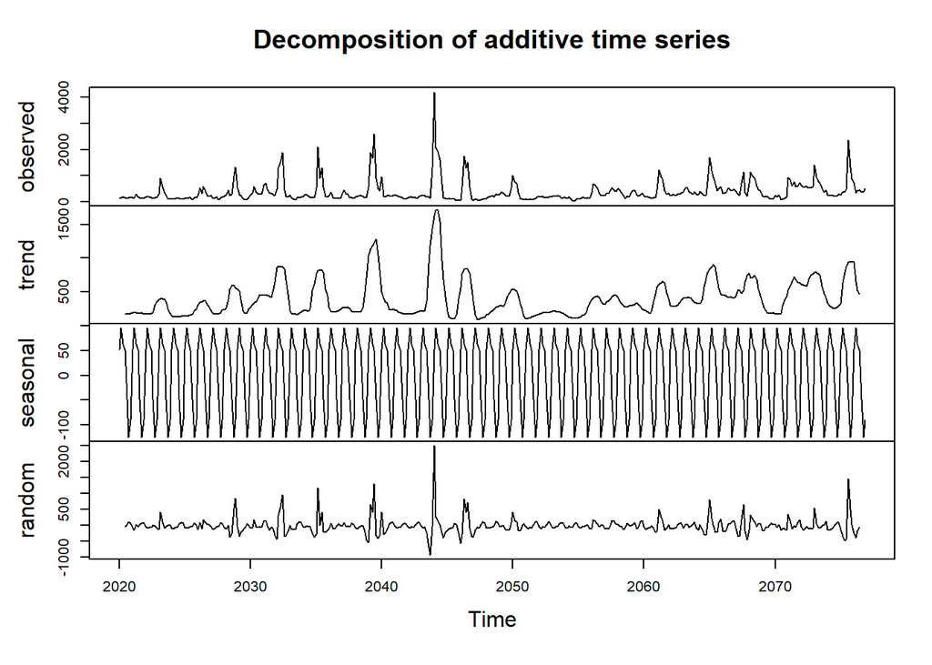

```
##
## #######################
## # KPSS Unit Root Test #
## #######################
##
## Test is of type: mu with 5 lags.
##
## Value of test-statistic is: 0.0066
##
## Critical value for a significance level of:
##                 10pct  5pct 2.5pct  1pct
## critical values 0.347 0.463  0.574 0.739
```

As we can see, the ACF plot shows that there’s an exponential decay. Also, PCF graph shows that lag-1 is significant and starting from lag-2, almost every lag is negative, and lag-3 has the highest significance in the negative domain. There’s no seasonal features observed in these plots.

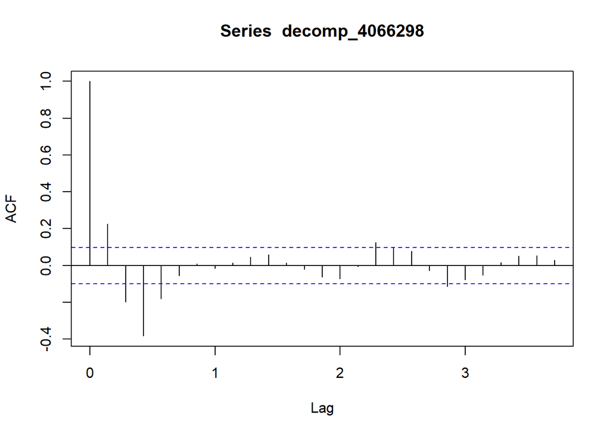

```r
acf(decomp_4066298, na.action = na.pass)
```

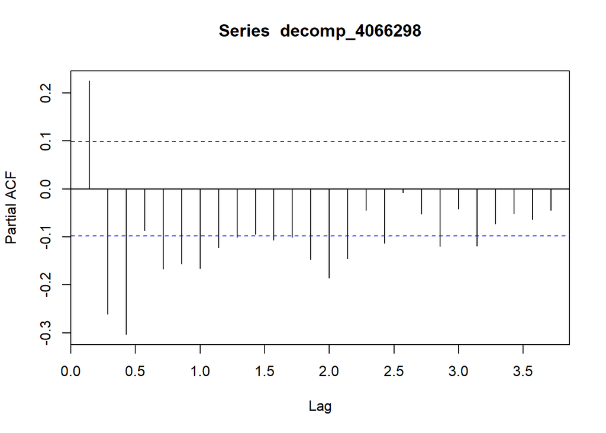

```r
pacf(decomp_4066298, na.action = na.pass)
```

### Task 2

According the plots above, we should use an ARIMA model with c(1, 0, 0) to observe the outputs. After that, I’ve tried (2, 0, 0), (3, 0, 0), (4, 0, 0) to see the difference between the models. And after the 4th order, it was not efficient to increase the model complexity. Therefore, I’ve selected my model as (4, 0, 0).

```r
model1 <- arima(decomp_4066298, order = c(1,0,0))
summary(model1)
```

```
##
## Call:
## arima(x = decomp_4066298, order = c(1, 0, 0))
##
## Coefficients:
##          ar1  intercept
##       0.2243    -0.1281
## s.e.  0.0491    16.7156
##
## sigma^2 estimated as 66162:  log likelihood = -2738.79,  aic = 5483.58
##
## Training set error measures:
##                      ME     RMSE      MAE      MPE     MAPE      MASE
## Training set -0.0142147 257.2201 138.4546 25.66661 173.8286 0.8404375
##                    ACF1
## Training set 0.05905702
```

```r
model2 <- arima(decomp_4066298, order = c(2,0,0))
summary(model2)
```

```
##
## Call:
## arima(x = decomp_4066298, order = c(2, 0, 0))
##
## Coefficients:
##          ar1      ar2  intercept
##       0.2828  -0.2598     -0.036
## s.e.  0.0486   0.0486     12.828
##
## sigma^2 estimated as 61655:  log likelihood = -2725,  aic = 5458
##
## Training set error measures:
##                      ME     RMSE     MAE      MPE     MAPE      MASE       ACF1
## Training set 0.03105885 248.3046 132.356 115.1177 171.4438 0.8034182 -0.0781715
```

```r
model3 <- arima(decomp_4066298, order = c(3,0,0))
summary(model3)
```

```
##
## Call:
## arima(x = decomp_4066298, order = c(3, 0, 0))
##
## Coefficients:
##          ar1      ar2      ar3  intercept
##       0.2032  -0.1743  -0.3034     0.2411
## s.e.  0.0480   0.0482   0.0480     9.3799
##
## sigma^2 estimated as 55931:  log likelihood = -2706,  aic = 5421.99
##
## Training set error measures:
##                      ME     RMSE      MAE      MPE     MAPE      MASE
## Training set 0.07773755 236.4973 128.9465 225.8142 331.8393 0.7827222
##                     ACF1
## Training set -0.02655702
```

```r
model4 <- arima(decomp_4066298, order = c(4,0,0))
summary(model4)
```

```
##
## Call:
## arima(x = decomp_4066298, order = c(4, 0, 0))
##
## Coefficients:
##          ar1      ar2      ar3      ar4  intercept
##       0.1759  -0.1900  -0.2858  -0.0890     0.3208
## s.e.  0.0502   0.0488   0.0488   0.0502     8.5779
##
## sigma^2 estimated as 55483:  log likelihood = -2704.43,  aic = 5420.87
##
## Training set error measures:
##                      ME     RMSE      MAE      MPE     MAPE     MASE
## Training set 0.09661878 235.5487 128.6532 109.5407 223.2888 0.780942
##                     ACF1
## Training set -0.01464148
```

By incrementing the order of the ARIMA model 1 at each time, we can see the change in the AIC value and after the (4, 0, 0) model, it was not efficient to increase the model complexity. Therefore, I’d like to use (4, 0, 0) in the future tasks.

### Task 3

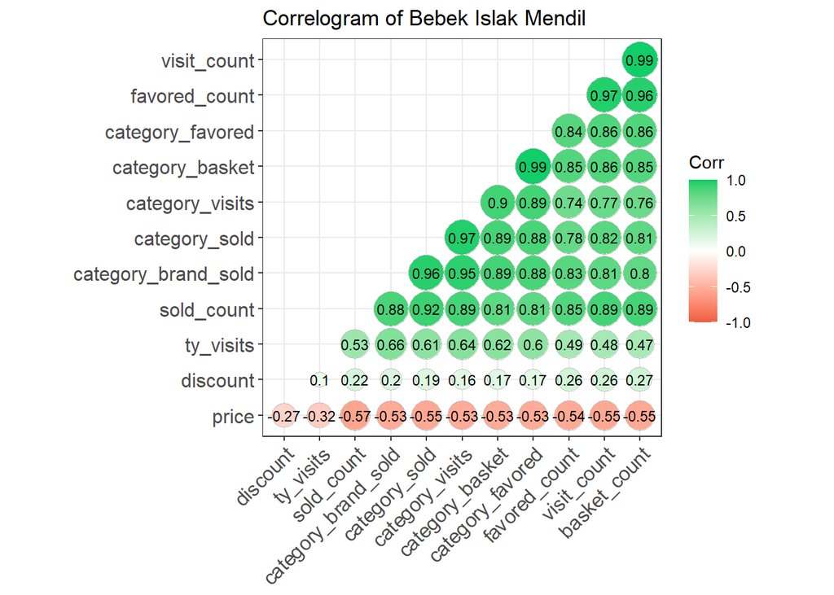

```r
cor_plot(data_4066298, "Bebek Islak Mendil")
```

In the project, most of the variables (basket_count, favored_count, category_sold) are not independent. Therefore, using multiple regressors on a model for this data set is not a suitable approach. It will arise multicollinearity problem.

### Task 4

By looking the correlation plot, I’ve selected 3 distinct features to feed my ARIMA models and category_sold was the one that has given the smallest AIC value. Thus, I’ve selected my regressor as category_sold.

The block below tries visit_count as the regressor for the selected model in the previous task.

```r
data_4066298_norm <- data_manip("4066298", normal = T)
model5 <- arima(decomp_4066298, order = c(4,0,0), xreg = cbind(data_4066298_norm$visit_count))
summary(model5)
```

```
##
## Call:
## arima(x = decomp_4066298, order = c(4, 0, 0), xreg = cbind(data_4066298_norm$visit_count))
##
## Coefficients:
##          ar1     ar2      ar3     ar4  intercept
##       0.4527  0.0385  -0.0926  0.1770    -1.5154
## s.e.  0.0558  0.0578   0.0565  0.0506    22.5026
##       cbind(data_4066298_norm$visit_count)
##                                   235.2609
## s.e.                               17.8421
##
## sigma^2 estimated as 36265:  log likelihood = -2620.81,  aic = 5255.62
##
## Training set error measures:
##                      ME     RMSE      MAE       MPE     MAPE      MASE
## Training set -0.5359311 190.4334 116.0973 -24.01496 319.7511 0.7047259
##                     ACF1
## Training set -0.02183769
```

The block below tries basket_count as the regressor for the selected model in the previous task.

```r
model6 <- arima(decomp_4066298, order = c(4,0,0), xreg = cbind(data_4066298_norm$basket_count))
summary(model6)
```

```
##
## Call:
## arima(x = decomp_4066298, order = c(4, 0, 0), xreg = cbind(data_4066298_norm$basket_count))
##
## Coefficients:
##          ar1     ar2      ar3     ar4  intercept
##       0.4651  0.0650  -0.0753  0.1770    -1.4071
## s.e.  0.0540  0.0577   0.0562  0.0513    25.6317
##       cbind(data_4066298_norm$basket_count)
##                                    248.3444
## s.e.                                16.9054
##
## sigma^2 estimated as 35520:  log likelihood = -2616.76,  aic = 5247.52
##
## Training set error measures:
##                      ME    RMSE      MAE       MPE    MAPE      MASE
## Training set -0.6658279 188.467 113.7633 -57.15185 361.952 0.6905579
##                     ACF1
## Training set -0.02289932
```

The block below tries category_sold as the regressor for the selected model in the previous task.

```r
model7 <- arima(decomp_4066298, order = c(4,0,0), xreg = cbind(data_4066298_norm$category_sold))
summary(model7)
```

```
##
## Call:
## arima(x = decomp_4066298, order = c(4, 0, 0), xreg = cbind(data_4066298_norm$category_sold))
##
## Coefficients:
##          ar1      ar2      ar3     ar4  intercept
##       0.7826  -0.1097  -0.1751  0.2341    -1.7393
## s.e.  0.0800   0.0655   0.0622  0.0536    30.7477
##       cbind(data_4066298_norm$category_sold)
##                                     314.3258
## s.e.                                 20.7510
##
## sigma^2 estimated as 27180:  log likelihood = -2564.41,  aic = 5142.81
##
## Training set error measures:
##                      ME     RMSE      MAE       MPE     MAPE      MASE
## Training set -0.7215695 164.8625 109.0541 -174.6048 444.4641 0.6619725
##                    ACF1
## Training set 0.01842316
```

As we can see, category_sold has given the smallest AIC, thus my predictive model is utilizing category_sold as its external regressor. And the block below creates a model with the given specifications, constructs the predictions and plot them to compare the results.

The plot shows that predictions are way more than the actual values. This may occur due to the lack of seasonality in our data, since the data set has seasonal features, but we did not create a model with a seasonality option. Let’s check the WMAPE value for gaining more insight.

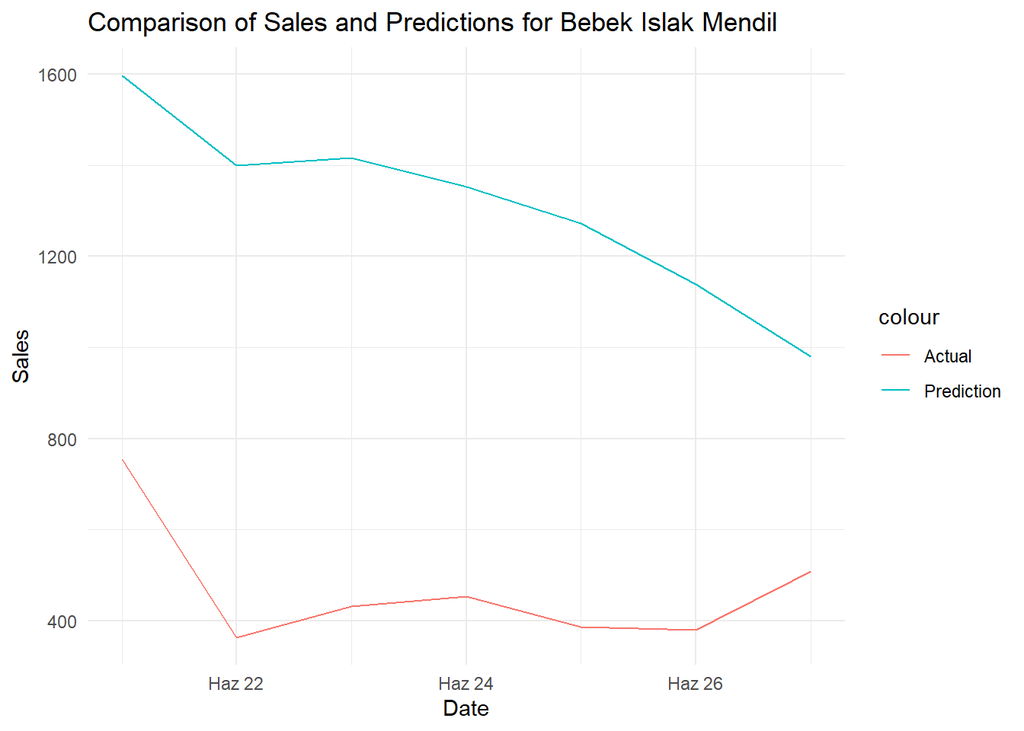

```r
comparison_4066298 <- forecast_func(data = data_4066298$sold_count, ar_order = c(4,0,0), reg_matrix = cbind(data_4066298_norm$category_sold))
comparison_4066298 <- data.table(cbind(data_4066298$event_date[(nrow(data_4066298)-6):nrow(data_4066298)], comparison_4066298))
colnames(comparison_4066298) <- c("event_date", "Actual", "Prediction")
plotting(comparison_4066298,product_name = "Bebek Islak Mendil", col = "",num =2)
```

It is not a surprise for us to see that much WMAPE score, since our predictions are way off than the actual data. This also indicates that our model has functioned insufficiently and there’s much work to be done in future to improve this model.

```r
accu(comparison_4066298$Actual, comparison_4066298$Prediction)
```

```
##   n     mean       sd        CV     FBias     MAPE     RMSE      MAD     MADP
## 1 7 468.1429 135.5242 0.2894933 -1.793841 1.920841 857.1184 839.7741 1.793841
##      WMAPE
## 1 1.793841
```

## 6) Şarj Edilebilir Diş Fırçası

### Task 1

Let’s examine the data of the “Şarj Edilebilir Diş Fırçası”.

```r
data_32939029 <- data_manip("32939029", normal = F)
head(data_32939029)
```

```
##    event_date    price sold_count visit_count basket_count favored_count
## 1: 2020-05-25 112.9000         74        3113          323           369
## 2: 2020-05-26 115.8495        101        3704          411           451
## 3: 2020-05-27 114.1078        103        3617          398           439
## 4: 2020-05-28 115.1035         84        3428          370           413
## 5: 2020-05-29 126.1038         52        2669          257           309
## 6: 2020-05-30 127.5000         38        2179          184           241
##    category_sold category_visits category_basket category_favored
## 1:          1193            1231           48380             4132
## 2:          1351            1419           52014             4647
## 3:          1071            1125           46574             3876
## 4:           927             978           42764             3336
## 5:           810             851           39533             2878
## 6:           842             890           41007             3087
##    category_brand_sold ty_visits    discount
## 1:                6411 119209111   0.0000000
## 2:                7222 122676139  -2.9495050
## 3:                5785 116532038   1.7417380
## 4:                5046 113372216  -0.9956854
## 5:                4445 110804859 -11.0003938
## 6:                4610 111507042  -1.3961538
```

After the decomposition, let’s check the KPSS test results for stationary. The test shows that the value is way less than the significance threshold, thus we fail to reject the null hypothesis, which is the stationary of the data.

Also, if we try to decompose the data with a weekly and monthly perspective, we get an error since the dataset has no data that can support at least two periods. Therefore, we can only continue with the daily decomposition.

Furthermore, let’s analyze the ACF and PCF plots.

```r
decomp_32939029 <- decomp(data_32939029, 7)
```

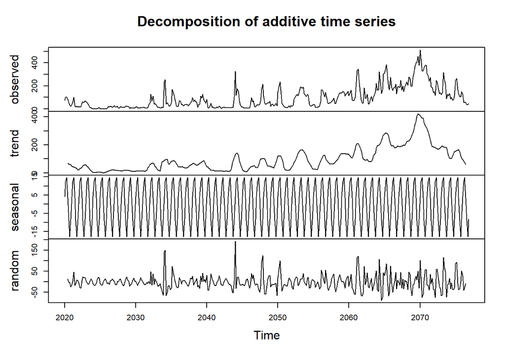

```
##
## #######################
## # KPSS Unit Root Test #
## #######################
##
## Test is of type: mu with 5 lags.
##
## Value of test-statistic is: 0.0071
##
## Critical value for a significance level of:
##                 10pct  5pct 2.5pct  1pct
## critical values 0.347 0.463  0.574 0.739
```

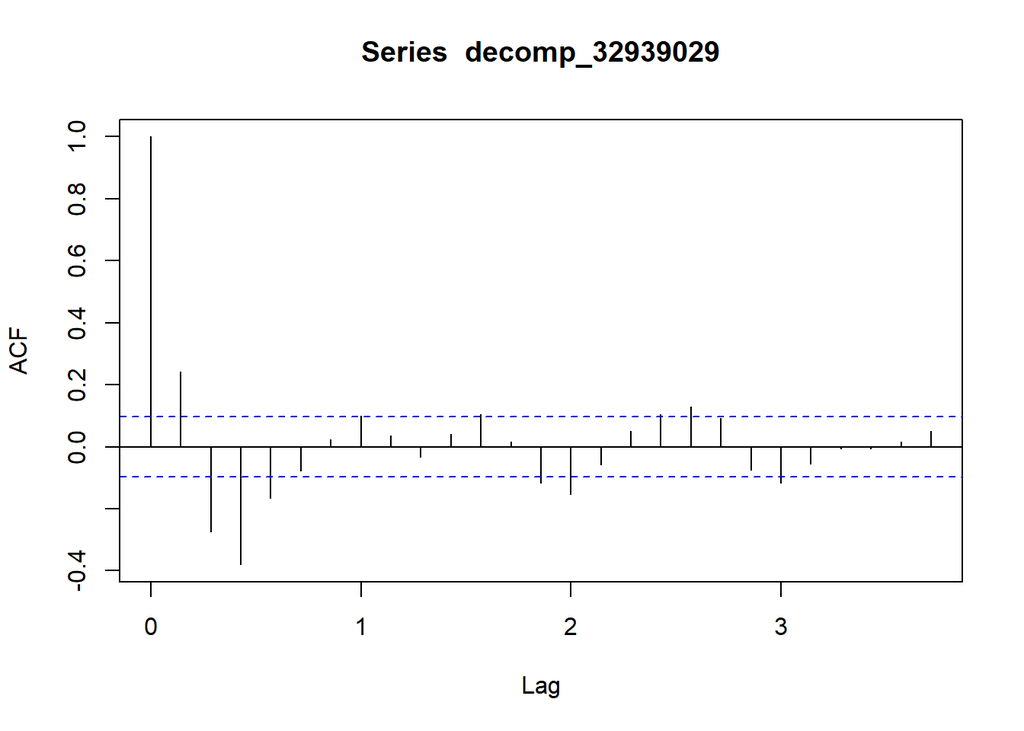

```r
acf(decomp_32939029, na.action = na.pass)
```

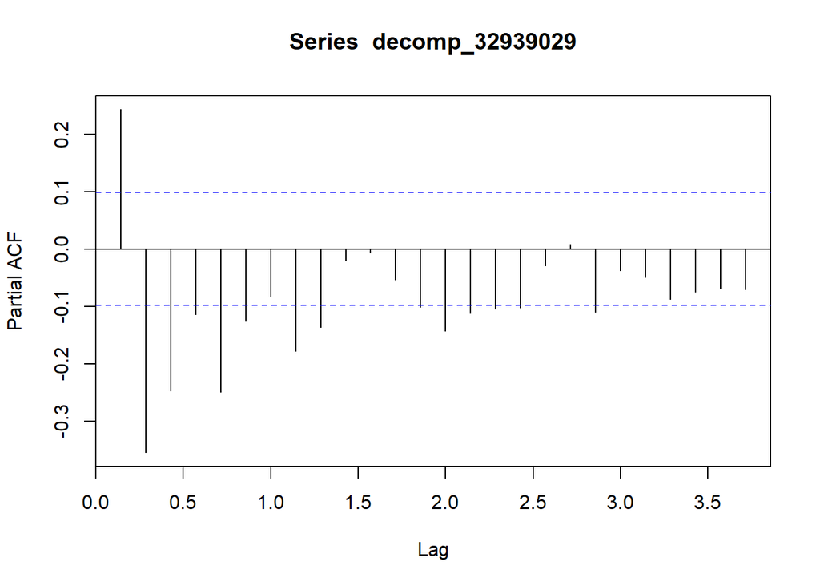

```r
pacf(decomp_32939029, na.action = na.pass)
```

### Task 2

According the plots above, we should use an ARIMA model with c(1, 0, 0) to observe the outputs. After that, I’ve tried (2, 0, 0), (3, 0, 0), (4, 0, 0) to see the difference between the models. And after the 4th order, it was not efficient to make the model more complex, thus I’ve selected (4, 0, 0) as my baseline model.

```r
model1 <- arima(decomp_32939029, order = c(1,0,0))
summary(model1)
```

```
##
## Call:
## arima(x = decomp_32939029, order = c(1, 0, 0))
##
## Coefficients:
##          ar1  intercept
##       0.2424    -0.0382
## s.e.  0.0489     2.3229
##
## sigma^2 estimated as 1219:  log likelihood = -1953.98,  aic = 3913.96
##
## Training set error measures:
##                      ME     RMSE      MAE      MPE     MAPE      MASE
## Training set -0.0065658 34.91608 24.04219 145.0193 165.2094 0.8454933
##                    ACF1
## Training set 0.08650671
```

```r
model2 <- arima(decomp_32939029, order = c(2,0,0))
summary(model2)
```

```
##
## Call:
## arima(x = decomp_32939029, order = c(2, 0, 0))
##
## Coefficients:
##          ar1      ar2  intercept
##       0.3283  -0.3536    -0.0156
## s.e.  0.0471   0.0471     1.6074
##
## sigma^2 estimated as 1065:  log likelihood = -1927.63,  aic = 3863.27
##
## Training set error measures:
##                       ME     RMSE      MAE      MPE     MAPE      MASE
## Training set 0.004271236 32.64089 22.67419 86.33321 245.7932 0.7973849
##                     ACF1
## Training set -0.08688788
```

```r
model3 <- arima(decomp_32939029, order = c(3,0,0))
summary(model3)
```

```
##
## Call:
## arima(x = decomp_32939029, order = c(3, 0, 0))
##
## Coefficients:
##          ar1      ar2      ar3  intercept
##       0.2403  -0.2727  -0.2472     0.0123
## s.e.  0.0488   0.0483   0.0488     1.2490
##
## sigma^2 estimated as 999.7:  log likelihood = -1915.21,  aic = 3840.42
##
## Training set error measures:
##                       ME     RMSE      MAE    MPE     MAPE      MASE
## Training set 0.005329131 31.61751 21.55049 44.657 193.8696 0.7578676
##                     ACF1
## Training set -0.02782988
```

```r
model4 <- arima(decomp_32939029, order = c(4,0,0))
summary(model4)
```

```
##
## Call:
## arima(x = decomp_32939029, order = c(4, 0, 0))
##
## Coefficients:
##          ar1      ar2      ar3      ar4  intercept
##       0.2119  -0.3040  -0.2195  -0.1144     0.0182
## s.e.  0.0501   0.0499   0.0500   0.0501     1.1140
##
## sigma^2 estimated as 986.4:  log likelihood = -1912.62,  aic = 3837.23
##
## Training set error measures:
##                       ME     RMSE      MAE      MPE     MAPE      MASE
## Training set 0.001371699 31.40738 21.35659 32.94868 193.1814 0.7510488
##                    ACF1
## Training set -0.0279598
```

By incrementing the order of the ARIMA model 1 at each time, we can see the change in the AIC value and after the (4, 0, 0) model, it was not efficient to increase the model complexity. Therefore, I’d like to use (4, 0, 0) in the future tasks.

### Task 3

[figure not shown]

```r
cor_plot(data_32939029, "Dik Süpürge")
```

In the project, most of the variables (basket_count, favored_count, category_sold) are not independent. Therefore, using multiple regressors on a model for this data set is not a suitable approach. It will arise multicollinearity problem.

### Task 4

The block below tries visit_count as the regressor for the selected model in the previous task.

```r
data_32939029_norm <- data_manip("32939029", normal = T)
model5 <- arima(decomp_32939029, order = c(4,0,0), xreg = cbind(data_32939029_norm$visit_count))
summary(model5)
```

```
##
## Call:
## arima(x = decomp_32939029, order = c(4, 0, 0), xreg = cbind(data_32939029_norm$visit_count))
##
## Coefficients:
##          ar1      ar2      ar3      ar4  intercept
##       0.2194  -0.2881  -0.2107  -0.0784    -0.0316
## s.e.  0.0525   0.0515   0.0512   0.0546     1.1309
##       cbind(data_32939029_norm$visit_count)
##                                      6.3921
## s.e.                                 1.3942
##
## sigma^2 estimated as 922.2:  log likelihood = -1899.34,  aic = 3812.68
##
## Training set error measures:
##                       ME     RMSE      MAE      MPE     MAPE      MASE
## Training set 0.007547913 30.36736 20.86472 86.85503 194.9023 0.7337513
##                     ACF1
## Training set -0.01504189
```

The block below tries basket_count as the regressor for the selected model in the previous task.

```r
model6 <- arima(decomp_32939029, order = c(4,0,0), xreg = cbind(data_32939029_norm$basket_count))
summary(model6)
```

```
##
## Call:
## arima(x = decomp_32939029, order = c(4, 0, 0), xreg = cbind(data_32939029_norm$basket_count))
##
## Coefficients:
##          ar1      ar2      ar3      ar4  intercept
##       0.2280  -0.2830  -0.2069  -0.0657    -0.0329
## s.e.  0.0541   0.0522   0.0518   0.0568     1.1481
##       cbind(data_32939029_norm$basket_count)
##                                       7.2284
## s.e.                                  1.5119
##
## sigma^2 estimated as 908.8:  log likelihood = -1896.45,  aic = 3806.9
##
## Training set error measures:
##                       ME    RMSE      MAE      MPE     MAPE      MASE
## Training set 0.007727977 30.1456 20.77369 93.52427 205.3973 0.7305498
##                     ACF1
## Training set -0.01144861
```

As we can see, basket_count has given the smallest AIC, thus my predictive model is utilizing basket_count as its external regressor. And the block below creates a model with the given specifications, constructs the predictions and plot them to compare the results.

The plot shows that predictions are way more than the actual values for quite a time, buy they get closer at the end of the predictions. This may occur due to the lack of seasonality in our data, since the data set has seasonal features, but we did not create a model with a seasonality option. Let’s check the WMAPE value for gaining more insight.

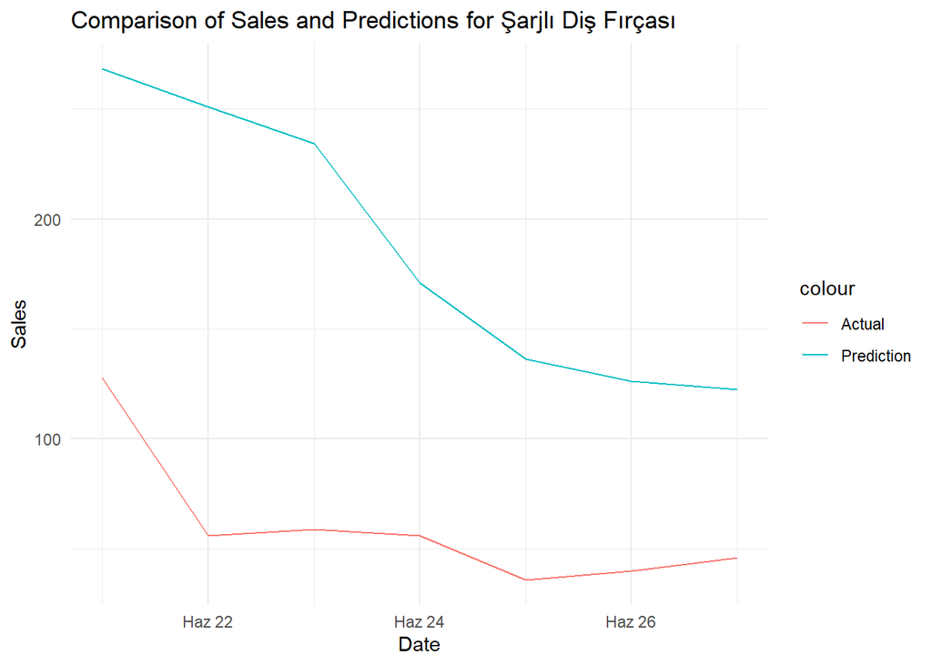

```r
comparison_32939029 <- forecast_func(data = data_32939029$sold_count, ar_order = c(4,0,0), reg_matrix = cbind(data_32939029_norm$basket_count))
comparison_32939029 <- data.table(cbind(data_32939029$event_date[(nrow(data_32939029)-6):nrow(data_32939029)], comparison_32939029))
colnames(comparison_32939029) <- c("event_date", "Actual", "Prediction")
plotting(comparison_32939029,product_name = "Şarjlı Diş Fırçası", col = "",num =2)
```

It is not a surprise for us to see that much WMAPE score, since our predictions are way off than the actual data. This also indicates that our model has functioned insufficiently and there’s much work to be done in future to improve this model.

```r
accu(comparison_32939029$Actual, comparison_32939029$Prediction)
```

```
##   n     mean       sd        CV     FBias     MAPE    RMSE      MAD     MADP
## 1 7 60.14286 31.16851 0.5182413 -2.112039 2.316722 133.719 127.0241 2.112039
##      WMAPE
## 1 2.112039
```